# Action_potentials_tut_part_2

This tutorial provides an overview of action potentials and highlights how their characteristics differ across regions—for example, between cortical neurons and various excitable organ cells. It also introduces how to implement action-potential models in code and reviews several commonly used modeling frameworks. (coding part)

1. Hodgkin–Huxley Model
2. Code: Hodgkin–Huxley System
3. Leaky Integrate-and-Fire (LIF) — Derivation & Equations
4. Bursting Leaky Integrate-and-Fire (LIF) Model — Equations
5. Code: Bursting Leaky Integrate-and-Fire (LIF) System — Equations
6. Bursting and Spiking Leaky Integrate-and-Fire (LIF) Model
7. Code: Bursting and Spiking Leaky Integrate-and-Fire (LIF) System
8. Derivation of the Izhikevich Neuron Model
9. Code for Izhikevich Neuron Model System
10. Electrophysiological Model for Plateau-Type Neurons (ICC Slow-Wave Model)
11. Code for ICC slow wave potential
12. Modified FitzHugh–Nagumo Model for Plateau-Like Slow Waves
13. Code for Modified FitzHugh–Nagumo Model for Plateau-Like Slow Waves
14. Explanation of the Modified LIF for Plateau like Action Potential Model
15. Code for Modified LIF Model

# Hodgkin–Huxley Model [1]

## System of ODEs (Full Hodgkin–Huxley Model)

$$ \boxed{ \begin{aligned} C_m \frac{dV_m}{dt} &= I_{ext} - \bar{g}_{Na} m^3 h (V_m - E_{Na}) - \bar{g}_{K} n^4 (V_m - E_{K}) - \bar{g}_{L} (V_m - E_{L}) \\ \frac{dm}{dt} &= \alpha_m(V_m)(1 - m) - \beta_m(V_m)m \\ \frac{dh}{dt} &= \alpha_h(V_m)(1 - h) - \beta_h(V_m)h \\ \frac{dn}{dt} &= \alpha_n(V_m)(1 - n) - \beta_n(V_m)n \end{aligned} } $$

## Empirical Rate Functions (from Squid Axon Data)

$$ \begin{aligned} \alpha_n &= 0.01 \cdot \frac{(V_m + 55)}{1 - e^{-\frac{(V_m + 55)}{10}}} \\ \beta_n &= 0.125 \cdot e^{-\frac{(V_m + 65)}{80}} \\ \alpha_m &= 0.1 \cdot \frac{(V_m + 40)}{1 - e^{-\frac{(V_m + 40)}{10}}}\\ \beta_m &= 4 \cdot e^{-\frac{(V_m + 65)}{18}}\\ \alpha_h &= 0.07 \cdot e^{-\frac{(V_m + 65)}{20}}\\ \beta_h &= \frac{1}{1 + e^{-\frac{(V_m + 35)}{10}}}\\ \end{aligned} $$

## Interpretation of Each Term

| Term | Physical Meaning |
| --- | --- |
| $C_m \frac{dV_m}{dt}$ | Capacitive current (change in membrane potential) |
| $I_{ext}$ | External applied current |
| $I_{Na}$ | Inward depolarizing sodium current |
| $I_{K}$ | Outward repolarizing potassium current |
| $I_{L}$ | Passive leak current |
| $m, h, n$ | Voltage-dependent gating probabilities |

## Simulated Action Potential

When a depolarizing $I_{ext}$ is applied:

1. **Na⁺ activation (m↑)** → rapid depolarization
2. **Na⁺ inactivation (h↓)** and **K⁺ activation (n↑)** → repolarization
3. **K⁺ channels remain open** → hyperpolarization
4. **Return to resting potential** as gates recover

## Summary of the Hodgkin–Huxley Model

| Component | Description | Equation |
| --- | --- | --- |
| **Membrane equation** | Current balance | $C_m \frac{dV_m}{dt} = I_{ext} - (I_{Na} + I_{K} + I_{L})$ |
| **Na⁺ current** | Voltage-gated, fast | $I_{Na} = \bar{g}_{Na} m^3 h (V_m - E_{Na})$ |
| **K⁺ current** | Voltage-gated, slow | $I_{K} = \bar{g}_{K} n^4 (V_m - E_{K})$ |
| **Leak current** | Passive | $I_{L} = \bar{g}_{L} (V_m - E_{L})$ |
| **Gating dynamics** | Channel kinetics | $\frac{dx}{dt} = \alpha_x(1 - x) - \beta_x x$ |

## Final Form: The Hodgkin–Huxley System

$$ \boxed{ \begin{cases} C_m \frac{dV_m}{dt} = I_{ext} - \bar{g}_{Na} m^3 h (V_m - E_{Na}) - \bar{g}_{K} n^4 (V_m - E_{K}) - \bar{g}_{L} (V_m - E_{L}) \\ \frac{dm}{dt} = \alpha_m(V_m)(1 - m) - \beta_m(V_m)m \\ \frac{dh}{dt} = \alpha_h(V_m)(1 - h) - \beta_h(V_m)h \\ \frac{dn}{dt} = \alpha_n(V_m)(1 - n) - \beta_n(V_m)n \end{cases} } $$

This four-dimensional nonlinear ODE system can reproduce the **shape, threshold, and refractory behavior** of real neuronal action potentials.

## Code: Hodgkin–Huxley System

$I_{ext}$ = 10.0 External applied current (μA/cm^2)

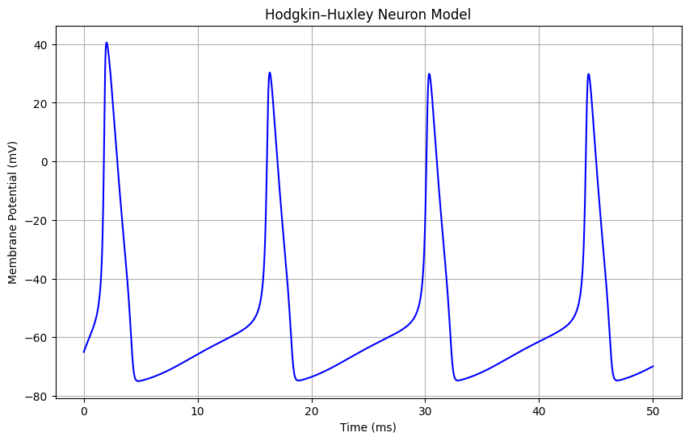

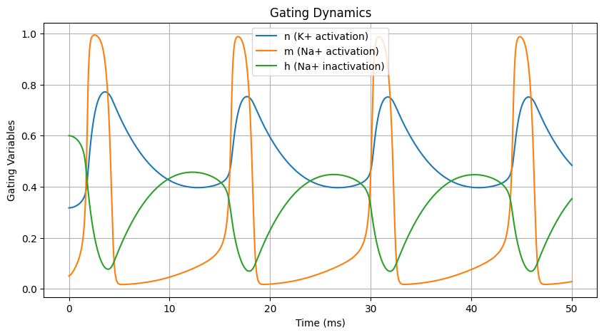

```python
import numpy as np
import matplotlib.pyplot as plt
from scipy.integrate import solve_ivp

# Hodgkin-Huxley model
def hodgkin_huxley(t, y, I_ext):
    Vm, n, m, h = y  # Unpack state variables

    # Model parameters
    Cm = 1.0     # μF/cm^2
    gNa = 120.0  # mS/cm^2
    gK = 36.0    # mS/cm^2
    gL = 0.3     # mS/cm^2
    ENa = 50.0   # mV
    EK = -77.0   # mV
    EL = -50.0   # mV

    # Gating kinetics
    alpha_n = 0.01 * (Vm + 55) / (1 - np.exp(-(Vm + 55) / 10))
    beta_n = 0.125 * np.exp(-(Vm + 65) / 80)
    alpha_m = 0.1 * (Vm + 40) / (1 - np.exp(-(Vm + 40) / 10))
    beta_m = 4 * np.exp(-(Vm + 65) / 18)
    alpha_h = 0.07 * np.exp(-(Vm + 65) / 20)
    beta_h = 1 / (1 + np.exp(-(Vm + 35) / 10))

    # Ionic currents
    I_Na = gNa * m**3 * h * (Vm - ENa)
    I_K = gK * n**4 * (Vm - EK)
    I_L = gL * (Vm - EL)

    # Membrane potential derivative
    dVm = (1 / Cm) * (-I_Na - I_K - I_L + I_ext)
    # Gating variable derivatives
    dn = alpha_n * (1 - n) - beta_n * n
    dm = alpha_m * (1 - m) - beta_m * m
    dh = alpha_h * (1 - h) - beta_h * h

    return [dVm, dn, dm, dh]


# Simulation parameters
t_span = (0, 50)   # ms
t_eval = np.linspace(t_span[0], t_span[1], 2000)
I_ext = 10.0       # External applied current (μA/cm^2)

# Initial conditions: [Vm, n, m, h]
y0 = [-65, 0.317, 0.05, 0.6]

# Solve ODE
sol = solve_ivp(hodgkin_huxley, t_span, y0, t_eval=t_eval, args=(I_ext,), method='RK45')

# Extract results
Vm = sol.y[0]
n = sol.y[1]
m = sol.y[2]
h = sol.y[3]

# Plot results
plt.figure(figsize=(10, 6))
plt.plot(sol.t, Vm, 'b')
plt.title("Hodgkin–Huxley Neuron Model")
plt.xlabel("Time (ms)")
plt.ylabel("Membrane Potential (mV)")
plt.grid(True)
plt.show()

# Optional: plot gating variables
plt.figure(figsize=(10, 5))
plt.plot(sol.t, n, label='n (K+ activation)')
plt.plot(sol.t, m, label='m (Na+ activation)')
plt.plot(sol.t, h, label='h (Na+ inactivation)')
plt.xlabel("Time (ms)")
plt.ylabel("Gating Variables")
plt.title("Gating Dynamics")
plt.legend()
plt.grid(True)
plt.show()
```

# Computational Cost of the Hodgkin–Huxley (HH) Model

## Detailed Biophysical Representation

The HH model explicitly simulates sodium, potassium, and leak currents, each governed by nonlinear differential equations describing ion channel kinetics.

## High Computational Load

Multiple coupled ODEs must be solved simultaneously at every small time step, making simulations of even a single neuron time-consuming.

## Scalability Issues

Extending the HH model to large neural networks or multi-compartment systems increases computational cost exponentially, limiting its practical use in real-time or large-scale simulations.

# Need for Reduced Models

## Simplification for Efficiency

To overcome the computational burden, simplified neuron models are developed that retain key electrical behaviors while reducing mathematical complexity.

## Trade-off Between Accuracy and Speed

Reduced models approximate the essential spiking dynamics of neurons without replicating the full biophysical details of ionic conductances.

# Examples of Reduced Models

## Leaky Integrate-and-Fire (LIF) Model

- Represents the neuron as a simple RC circuit.
- Integrates input currents until a threshold is reached, then emits a spike and resets.
- Extremely fast and ideal for large network simulations.

## Izhikevich Model

- Combines computational efficiency with biological realism.
- Uses only two differential equations but can reproduce diverse neuronal firing patterns (regular spiking, bursting, chattering, etc.).
- Well-suited for real-time neural simulations and brain-inspired computing.

# Leaky Integrate-and-Fire (LIF) [2] — Derivation & Equations

## Model Setup (RC Circuit)

Represent the membrane as a capacitor $ C $ in parallel with a leak resistor $ R $ (or leak conductance $ g_L = 1/R $) and a resting potential $ V_L $.  
Input current $ I(t) $ injects charge into the capacitor.

**Kirchhoff’s current law:** $$ C\frac{dV}{dt} + \frac{V - V_L}{R} = I(t) $$

## Standard Differential Equation

Rearranging and using $ g_L = 1/R $ and $ \tau_m = RC = C/g_L $: $$ \tau_m \frac{dV}{dt} = -(V - V_L) + R\,I(t) $$ or equivalently, $$ \frac{dV}{dt} = -\frac{V - V_L}{\tau_m} + \frac{I(t)}{C} $$

## Spike Mechanism (Integrate-and-Fire Rule)

When $ V(t) $ reaches a threshold $ V_{\text{th}} $, a spike is emitted and the voltage is instantaneously reset: $$ \text{if } V(t^-) \ge V_{\text{th}} \quad \Rightarrow \quad V(t) \leftarrow V_{\text{reset}} \quad (\text{and optionally a refractory period}) $$

## Closed-Form Solution for Constant Input $ I(t) = I_0 $

Define the steady-state value: $$ V_{\infty} = V_L + R I_0 $$

The solution of the linear ODE is: $$ V(t) = V_{\infty} + \big(V(0) - V_{\infty}\big)e^{-t/\tau_m} $$

If reset at $ V_{\text{reset}} $ and we look for the interspike interval $ T $ satisfying $ V(T) = V_{\text{th}} $: $$ V_{\text{th}} = V_{\infty} + \big(V_{\text{reset}} - V_{\infty}\big)e^{-T/\tau_m} $$

Solving for $ T $: $$ T = \tau_m \ln\!\left(\frac{V_{\infty} - V_{\text{reset}}}{V_{\infty} - V_{\text{th}}}\right) $$

The firing rate is then: $$ f = \frac{1}{T} $$ (if no refractory period).

## Remarks

- The LIF model is **linear between spikes** and **computationally efficient**, easily solved analytically or with simple numerical methods.
- It captures **temporal integration** and **threshold-based firing**, but omits detailed spike shapes and ionic channel dynamics.

# Bursting Leaky Integrate-and-Fire (LIF) Model — Equations

## 1. Membrane Equation

The neuron membrane dynamics follow a modified LIF form:

$$ \tau_m \frac{dV}{dt} = - (V - E_L) + R \big( I_{\text{ext}} - I_{\text{adapt}} \big) $$

where:

- $ V(t) $: membrane potential (mV)
- $ E_L $: leak reversal potential (mV)
- $ \tau_m = R \, C $: membrane time constant (ms), here $ C = 1 \, \text{nF} $ for simplicity
- $ R $: membrane resistance (MΩ)
- $ I_{\text{ext}} $: external (input) current (nA)
- $ I_{\text{adapt}} $: adaptation current due to slow negative feedback (nA)

The adaptation current is given by: $$ I_{\text{adapt}} = b \, w $$ where $ b $ is the adaptation coupling constant (current gain).

## 2. Adaptation Variable Dynamics

The adaptation variable $ w(t) $ evolves slowly compared to the membrane potential and follows:

$$ \tau_w \frac{dw}{dt} = a \, (V - E_L) - w $$

where:

- $ \tau_w $: adaptation time constant (ms)
- $ a $: coupling constant controlling how $ V $ influences adaptation
- $ w(t) $: dimensionless variable representing accumulated adaptation (e.g., slow potassium conductance)

## 3. Spike and Reset Conditions

When the membrane potential reaches threshold $ V_{\text{th}} $:

$$ \text{if } V(t^-) \ge V_{\text{th}} \quad \Rightarrow \quad \begin{cases} V(t) \leftarrow V_{\text{reset}} \\ \text{(optional)}: w(t) \leftarrow w(t) + \Delta w \end{cases} $$

This reset mimics the spike emission and subsequent repolarization.  
In this implementation, $ \Delta w $ (spike-triggered adaptation) is optional but can enhance bursting.

## 4. Summary of Parameters**

| Symbol | Meaning | Typical Value |
| --- | --- | --- |
| $ E_L $ | Leak reversal potential | -70 mV |
| $ V_{\text{th}} $ | Spike threshold | -50 mV |
| $ V_{\text{reset}} $ | Reset potential | -70 mV |
| $ R $ | Membrane resistance | 10 MΩ |
| $ \tau_m $ | Membrane time constant | 10 ms (assuming $ C = 1 \text{nF} $) |
| $ \tau_w $ | Adaptation time constant | 100 ms |
| $ a $ | Voltage coupling coefficient | 0.01 |
| $ b $ | Adaptation gain for current | 0.5 |
| $ I_{\text{ext}} $ | External input current | 2.5 nA |

## 5. Model Behavior

- For low $ I_{\text{ext}} $: the neuron remains silent.
- For moderate $ I_{\text{ext}} $: produces **regular spiking**.
- For higher $ I_{\text{ext}} $ and slow adaptation ($ \tau_w $ large): produces **bursting** due to gradual build-up and decay of $ w(t) $.

## 6. Numerical Implementation

Using **Euler’s method** with time step $ dt $: $$ \begin{aligned} w_{i+1} &= w_i + \frac{dt}{\tau_w} \big[a(V_i - E_L) - w_i \big] \\ I_{\text{adapt}} &= b\,w_{i+1} \\ V_{i+1} &= V_i + \frac{dt}{\tau_m} \big[-(V_i - E_L) + R(I_{\text{ext}} - I_{\text{adapt}}) \big] \end{aligned} $$

Spiking condition: $$ \text{if } V_{i+1} \ge V_{\text{th}} \Rightarrow V_{i+1} = V_{\text{reset}} $$

## Code: Bursting Leaky Integrate-and-Fire (LIF) System

$I_{ext}$ = 2.5 External applied current (nA)

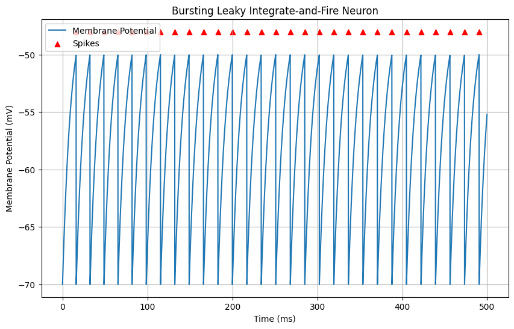

```python
import numpy as np
import matplotlib.pyplot as plt

def bursting_lif_model(T, dt, V_init, E_L, V_th, V_reset, R, tau_w, a, b, I_ext):
    """
    Simulates a bursting Leaky Integrate-and-Fire neuron with slow adaptation.

    Args:
        T (float): Total simulation time in ms.
        dt (float): Time step in ms.
        V_init (float): Initial membrane potential in mV.
        E_L (float): Leak reversal potential in mV.
        V_th (float): Spike threshold in mV.
        V_reset (float): Reset potential after spike in mV.
        R (float): Membrane resistance in MOhms.
        tau_w (float): Time constant for adaptation variable in ms.
        a (float): Adaptation coupling constant for voltage dependence.
        b (float): Adaptation coupling constant for current.
        I_ext (float or np.array): External input current in nA.

    Returns:
        tuple: (time_points, membrane_potential, spikes)
    """
    time_points = np.arange(0, T, dt)
    num_steps = len(time_points)

    V = np.zeros(num_steps)
    w = np.zeros(num_steps)  # Adaptation variable
    spikes = []

    V[0] = V_init
    tau_m = R * 1  # Assuming C=1nF for simplicity, so tau_m = R*C = R*1ms

    for i in range(num_steps - 1):
        # Update adaptation variable
        dw_dt = (a * (V[i] - E_L) - w[i]) / tau_w
        w[i+1] = w[i] + dw_dt * dt

        # Calculate adaptation current
        I_adapt = b * w[i+1]

        # Update membrane potential
        dV_dt = (- (V[i] - E_L) + R * (I_ext - I_adapt)) / tau_m
        V[i+1] = V[i] + dV_dt * dt

        # Check for spike
        if V[i+1] >= V_th:
            spikes.append(time_points[i+1])
            V[i+1] = V_reset
            # Increase adaptation variable upon spiking (optional, but common)
            # w[i+1] += some_spike_triggered_increase

    return time_points, V, spikes

# Model Parameters
T = 500  # ms
dt = 0.1 # ms
V_init = -70 # mV
E_L = -70  # mV
V_th = -50 # mV
V_reset = -70 # mV
R = 10   # MOhms (assuming C=1nF, tau_m = 10ms)
tau_w = 100 # ms (slow adaptation)
a = 0.01  # Adaptation coupling constant for voltage
b = 0.5   # Adaptation coupling constant for current
I_ext = 2.5 # nA (constant external current)

# Run simulation
time, V_trace, spikes = bursting_lif_model(T, dt, V_init, E_L, V_th, V_reset, R, tau_w, a, b, I_ext)

# Plotting
plt.figure(figsize=(10, 6))
plt.plot(time, V_trace, label='Membrane Potential')
plt.scatter(spikes, np.full_like(spikes, V_th + 2), color='red', marker='^', label='Spikes')
plt.xlabel('Time (ms)')
plt.ylabel('Membrane Potential (mV)')
plt.title('Bursting Leaky Integrate-and-Fire Neuron')
plt.grid(True)
plt.legend()
plt.show()
```

# Bursting and Spiking Leaky Integrate-and-Fire (LIF) Model

## 1. Membrane Potential Dynamics

**Differential Equation:**

$$ \tau_m \frac{dV}{dt} = -(V - V_\text{rest}) + R_m \times I(t) $$

**Discrete Implementation (Euler Method):**

$$ \begin{aligned} dV &= \frac{-(V[i-1] - V_\text{rest}) + R_m \times I[i]}{\tau_m} \\ V[i] &= V[i-1] + dV \times dt \end{aligned} $$

**Where:**

- $\tau_m$ = membrane time constant (20 ms)
- $R_m$ = membrane resistance (1 MΩ)
- $V_\text{rest}$ = resting potential (-65 mV)
- $I(t)$ = time-varying input current

## 2. Spike Generation and Reset

**Condition:** $$ V[i] \geq V_\text{th} $$

**Reset Operations:** $$ \begin{aligned} V[i-1] &= 20.0 \text{ mV} \quad \text{(spike visualization)} \\ V[i] &= V_\text{reset} \quad \text{(-65 mV)} \\ \text{refractory\_counter} &= \frac{t_\text{ref}}{dt} \end{aligned} $$

## 3. Refractory Period

**Refractory Condition:** $$ \text{refractory\_counter} > 0 $$

**Refractory Operations:** $$ \begin{aligned} V[i] &= V_\text{reset} \\ \text{refractory\_counter} &= \text{refractory\_counter} - 1 \end{aligned} $$

**Where:**

- $t_\text{ref}$ = 5.0 ms (refractory duration)
- $\text{ref\_steps} = t_\text{ref} / dt$ = 50 steps

## 4. Bursting Input Current Definition

**Square Wave Burst Pattern:**

$$ I(t) = \begin{cases} I_{\text{burst}} & \text{if } (t \bmod T_{\text{period}}) < (D \times T_{\text{period}}) \\ I_{\text{base}} & \text{otherwise} \end{cases} $$

**Where:**

- $I_\text{base}$ = 0.5 nA (baseline current)
- $I_\text{burst}$ = 100 nA (burst current)
- $T_\text{period}$ = 100 ms (burst cycle period)
- $D$ = 0.4 (duty cycle – fraction of time active)

**Mathematical Formulation:**

$$ I(t) = I_{\text{base}} + (I_{\text{burst}} - I_{\text{base}}) \times \text{square}(t/T_{\text{period}}, D) $$

Where $\text{square}()$ is a periodic square wave with duty cycle $D$.

## 5. Key Time Constants

- Membrane time constant: $\tau_m$ = 20 ms
- Refractory period: $t_\text{ref}$ = 5 ms
- Burst period: $T_\text{period}$ = 100 ms
- Burst duration: $D \times T_\text{period}$ = 40 ms
- Inter-burst interval: $(1-D) \times T_\text{period}$ = 60 ms

## 6. Voltage Thresholds

- Spike threshold: $V_\text{th}$ = -50 mV
- Reset potential: $V_\text{reset}$ = -65 mV
- Resting potential: $V_\text{rest}$ = -65 mV

## Physical Interpretation

This model demonstrates input-driven bursting:

- During burst phases ($I$ = 100 nA): Strong depolarization causes rapid spiking
- During silent phases ($I$ = 0.5 nA): Weak input below threshold, no spiking
- Refractory period prevents immediate re-spiking after each spike

The bursting pattern is entirely driven by the input current rather than intrinsic neuronal mechanisms like adaptation currents. This is a simpler form of bursting compared to adaptive bursting models.

## Code: Bursting and Spiking Leaky Integrate-and-Fire (LIF) System

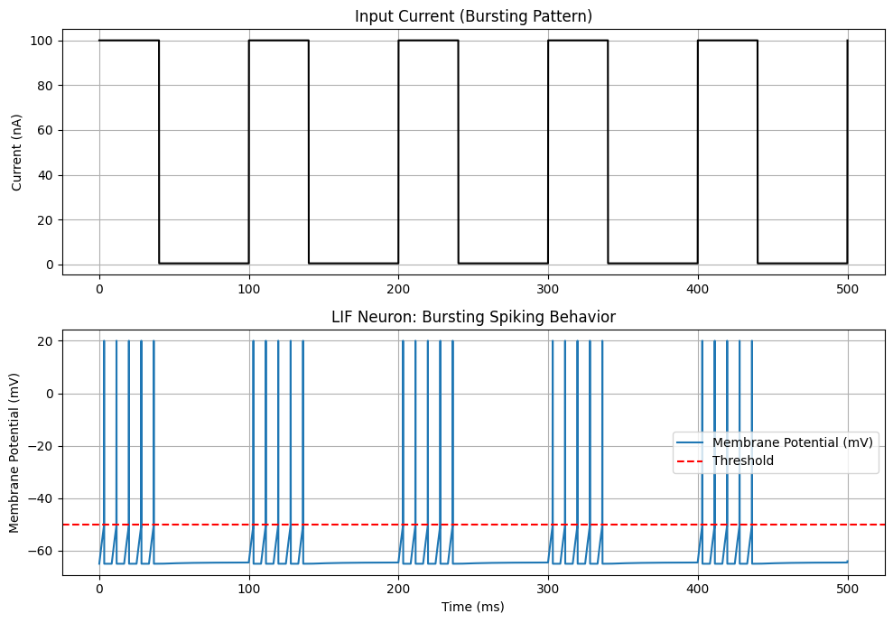

```
Number of spikes: 25
Spike times (ms): [  3.3  11.6  19.9  28.2  36.5 103.1 111.4 119.7 128.  136.3 203.1 211.4
 219.7 228.  236.3 303.1 311.4 319.7 328.  336.3 403.1 411.4 419.7 428.
 436.3]
```

```python
import numpy as np
import matplotlib.pyplot as plt

# Simulation parameters
T = 500        # total time (ms)
dt = 0.1       # time step (ms)
time = np.arange(0, T+dt, dt)

# LIF neuron parameters
tau_m = 20.0       # membrane time constant (ms)
R_m = 1.0          # membrane resistance (MΩ)
V_th = -50.0       # threshold potential (mV)
V_reset = -65.0    # reset potential (mV)
V_rest = -65.0     # resting potential (mV)

# Refractory period
t_ref = 5.0
ref_steps = int(t_ref / dt)

# Bursting input current: alternate between ON (high) and OFF (low)
I_base = 0.5                    # baseline input (nA)
I_burst = 100                   # burst input (nA)
burst_period = 100              # duration of one burst cycle (ms)
burst_on_ratio = 0.4            # fraction of time active per burst

I = np.zeros(len(time))
for i, t in enumerate(time):
    # Generate square-wave bursting current
    if (t % burst_period) < (burst_on_ratio * burst_period):
        I[i] = I_burst
    else:
        I[i] = I_base

# Initialize variables
V = np.zeros(len(time))
V[0] = V_rest
spikes = []
refractory_counter = 0

# Simulation loop
for i in range(1, len(time)):
    if refractory_counter > 0:
        V[i] = V_reset
        refractory_counter -= 1
        continue

    # Update membrane potential
    dV = (-(V[i-1] - V_rest) + R_m * I[i]) / tau_m
    V[i] = V[i-1] + dV * dt

    # Spike condition
    if V[i] >= V_th:
        V[i-1] = 20.0  # visualize spike
        V[i] = V_reset
        spikes.append(time[i])
        refractory_counter = ref_steps

# Plotting results
plt.figure(figsize=(10, 7))

plt.subplot(2, 1, 1)
plt.plot(time, I, 'k')
plt.title('Input Current (Bursting Pattern)')
plt.ylabel('Current (nA)')
plt.grid(True)

plt.subplot(2, 1, 2)
plt.plot(time, V, label='Membrane Potential (mV)')
plt.axhline(V_th, color='r', linestyle='--', label='Threshold')
plt.title('LIF Neuron: Bursting Spiking Behavior')
plt.xlabel('Time (ms)')
plt.ylabel('Membrane Potential (mV)')
plt.legend()
plt.grid(True)

plt.tight_layout()
plt.show()

print("Number of spikes:", len(spikes))
print("Spike times (ms):", np.round(spikes, 2))
```

# Derivation of the Izhikevich Neuron Model [3]

## 1. Introduction

The **Izhikevich model** (often misspelled as "izcehvich") is a computationally efficient neuron model developed by Eugene Izhikevich that can reproduce the diverse firing patterns of cortical neurons. It represents a brilliant compromise between biological plausibility and computational efficiency.

## 2. Motivation: From Hodgkin-Huxley to Simpler Models

The complex Hodgkin-Huxley model:

$$ \begin{aligned} C_m\frac{dV}{dt} &= -g_{Na}m^3h(V-E_{Na}) - g_Kn^4(V-E_K) - g_L(V-E_L) + I \\ \frac{dm}{dt} &= \alpha_m(V)(1-m) - \beta_m(V)m \\ \frac{dh}{dt} &= \alpha_h(V)(1-h) - \beta_h(V)h \\ \frac{dn}{dt} &= \alpha_n(V)(1-n) - \beta_n(V)n \end{aligned} $$

**Problems:**

- 4 coupled nonlinear differential equations
- Computationally expensive for large networks
- Difficult to analyze mathematically

## 3. Starting Point: Two-Dimensional Reduction

Izhikevich began with a class of simplified two-dimensional models:

$$ \begin{aligned} C\frac{dv}{dt} &= k(v - v_r)(v - v_t) - u + I \\ \frac{du}{dt} &= a(b(v - v_r) - u) \end{aligned} $$

**Where:**

- $ v $ = membrane potential
- $ u $ = recovery variable
- $ C $ = membrane capacitance
- $ v_r $ = resting potential
- $ v_t $ = threshold potential
- $ I $ = input current
- $ a, b, k $ = dimensionless parameters

## 4. Key Mathematical Transformation

Izhikevich applied a clever change of variables:

1. Shifted and scaled the voltage variable $ v \rightarrow V $
2. Absorbed parameters into new recovery variable $ u \rightarrow U $
3. Applied algebraic manipulation to obtain canonical form

## 5. The Izhikevich Model Equations

### Differential Equations:

$$ \begin{aligned} \frac{dV}{dt} &= 0.04V^2 + 5V + 140 - U + I \\ \frac{dU}{dt} &= a(bV - U) \end{aligned} $$

### Reset Condition:

$$ \text{If } V \geq 30 \text{ mV, then} \begin{cases} V \leftarrow c \\ U \leftarrow U + d \end{cases} $$

### Parameters:

- $ V $ = membrane potential
- $ U $ = recovery variable
- $ I $ = input current
- $ a $ = time scale of recovery variable
- $ b $ = sensitivity of recovery variable
- $ c $ = post-spike reset value of $ V $
- $ d $ = post-spike reset of recovery variable

## 6. Interpretation of the Equations

### Voltage Equation ($ dV/dt $):

$$ \frac{dV}{dt} = \underbrace{0.04V^2 + 5V + 140}_{\text{Spike generation}} - \underbrace{U}_{\text{Recovery feedback}} + \underbrace{I}_{\text{Input}} $$

- The quadratic term $ 0.04V^2 + 5V + 140 $ creates rapid spike generation
- Represents transformed version of $ k(v-v_r)(v-v_t) $
- Creates nonlinear excitation when $ V $ increases

### Recovery Equation ($ dU/dt $):

$$ \frac{dU}{dt} = a(bV - U) $$

- Linear equation describing recovery dynamics
- $ a $ = time scale (small $ a $ = slow recovery)
- $ b $ = sensitivity to subthreshold fluctuations

### Reset Mechanism:

- Computational efficiency: avoids simulating full spike downswing
- $ c $ determines after-spike voltage level
- $ d $ models potassium current effects and adaptation

## 7. Parameter Settings for Different Neuron Types

| Neuron Type | Parameters (a, b, c, d) | Firing Pattern |
| --- | --- | --- |
| **Regular Spiking (RS)** | (0.02, 0.2, -65, 8) | Adapting spikes |
| **Intrinsically Bursting (IB)** | (0.02, 0.2, -55, 4) | Initial bursting |
| **Chattering (CH)** | (0.02, 0.2, -50, 2) | High-frequency bursts |
| **Fast Spiking (FS)** | (0.1, 0.2, -65, 2) | Non-adapting high frequency |
| **Thalamo-Cortical (TC)** | (0.02, 0.25, -65, 0.05) | Low-threshold spikes |
| **Resonator (RZ)** | (0.1, 0.25, -65, 2) | Frequency-dependent |

## 8. Advantages and Limitations

### Advantages:

- **Computational efficiency**: 13 FLOPs per integration step vs. 1200 for H-H
- **Biological richness**: Reproduces 20+ firing patterns
- **Mathematical tractability**: Easier to analyze than H-H model

### Limitations:

- **Reset discontinuity** can cause numerical issues
- **Less biophysical detail** than H-H model
- **Parameters not directly measurable**

## 9. Summary

The Izhikevich model derivation involves:

1. **Starting** from a quadratic integrate-and-fire framework
2. **Transforming** variables to obtain canonical form
3. **Adding** reset conditions for computational efficiency
4. **Parameterizing** to match biological neuron types

The resulting model provides an excellent balance for large-scale neural simulations while maintaining biological realism.

## 10. Mathematical Formulation Summary

**Complete System:** $$ \begin{aligned} \frac{dV}{dt} &= 0.04V^2 + 5V + 140 - U + I \\ \frac{dU}{dt} &= a(bV - U) \\ \text{If } V \geq 30 &: \begin{cases} V \leftarrow c \\ U \leftarrow U + d \end{cases} \end{aligned} $$

This elegant formulation captures the essence of neural dynamics with minimal computational cost.

## Code for Izhikevich Neuron Model System

### Input Current Function

The input current $I(t)$ is defined as a square pulse:

$$ I(t) = \begin{cases} 20 & \text{for } 50 < t < 150 \\ 0 & \text{otherwise} \end{cases} $$

#### Parameters:

- **Amplitude**: 20 units
- **Start time**: $t = 50$ ms
- **End time**: $t = 150$ ms
- **Duration**: 100 ms

## Izhikevich Neuron Model Equations

This tutorial shows the equations behind the Izhikevich neuron simulation implemented in Python.

### 1. Membrane Potential Dynamics

The **membrane potential** (v) evolves according to:

$$ \frac{dv}{dt} = 0.04 v^2 + 5 v + 140 - u + I(t) $$

where:

- (v) = membrane potential (mV)
- (u) = recovery variable
- (I(t)) = input current

**Discrete (Euler) Implementation:**

$$ v[i] = v[i-1] + dt \left( 0.04 v[i-1]^2 + 5 v[i-1] + 140 - u[i-1] + I[i] \right) $$

### 2. Recovery Variable Dynamics

The recovery variable (u) evolves as:

$$ \frac{du}{dt} = a (b v - u) $$

**Discrete Implementation:**

$$ u[i] = u[i-1] + dt \cdot a \cdot (b \cdot v[i-1] - u[i-1]) $$

**Where the parameters are:**

- (a) = recovery time scale (0.02)
- (b) = sensitivity of (u) to (v) (0.2)

### 3. Spike Condition and Reset

When the membrane potential reaches the spike threshold ((v \ge 30) mV), the following reset occurs:

$$ \text{if } v[i] \ge 30: \begin{cases} v[i-1] = 30 \quad &\text{(cap spike for visualization)} \\ v[i] = c \quad &\text{(reset potential)} \\ u[i] = u[i] + d \quad &\text{(after-spike recovery)} \end{cases} $$

**Where:**

- (c) = reset potential (-65 mV)
- (d) = after-spike reset of (u) (8)

### 4. Input Current

In the simulation, the neuron receives a **pulse current**:

$$ I(t) = \begin{cases} 20 \text{ nA} & \text{if } 50 \le t \le 150 \text{ ms} \\ 0 & \text{otherwise} \end{cases} $$

### 5. Initial Conditions

- Membrane potential: (v(0) = v_\text{rest} = -65 , \text{mV})
- Recovery variable: (u(0) = b \cdot v(0) = -13)

### 6. Summary of Parameters

| Parameter | Description | Value |
| --- | --- | --- |
| a | Recovery time scale | 0.02 |
| b | Sensitivity of u to v | 0.2 |
| c | Membrane reset potential | -65 mV |
| d | After-spike recovery | 8 |
| dt | Time step | 0.25 ms |
| T | Total simulation time | 200 ms |

### 7. Physical Interpretation

- The **quadratic term** (0.04 v^2) allows for spike initiation.
- The **recovery variable (u)** acts like a slow K(^+)-like current, providing negative feedback.
- The **input current (I(t))** drives the neuron to spike.
- **Spike reset** ensures the neuron returns to baseline after firing.

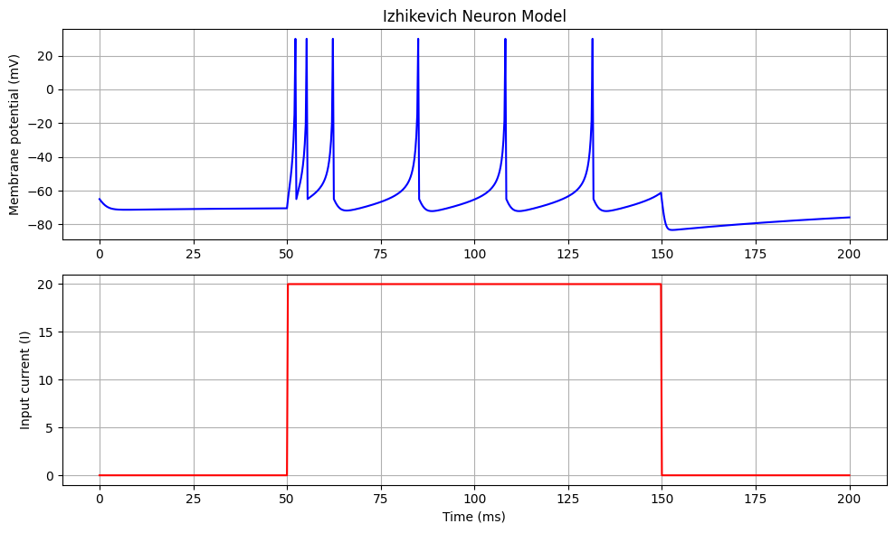

```python
import numpy as np
import matplotlib.pyplot as plt

# Simulation parameters
T = 200          # total time (ms)
dt = 0.25        # time step (ms)
time = np.arange(0, T + dt, dt)

# Izhikevich neuron parameters (change for different firing patterns)
a = 0.02         # recovery time scale
b = 0.2          # sensitivity of u to v
c = -65          # reset potential (mV)
d = 8            # after-spike reset of u

# Initial conditions
v = -65 * np.ones_like(time)  # membrane potential
u = b * v[0] * np.ones_like(time)  # recovery variable

# Input current (constant or pulse)
I = np.zeros_like(time)
I[(time > 50) & (time < 150)] = 20  # applied current

# Simulation loop
for i in range(1, len(time)):
    # Update equations
    v[i] = v[i-1] + dt * (0.04 * v[i-1]**2 + 5 * v[i-1] + 140 - u[i-1] + I[i])
    u[i] = u[i-1] + dt * a * (b * v[i-1] - u[i-1])

    # Spike condition
    if v[i] >= 30:
        v[i-1] = 30  # cap the spike for plotting
        v[i] = c
        u[i] += d

# Plot results
plt.figure(figsize=(10, 6))
plt.subplot(2, 1, 1)
plt.plot(time, v, 'b')
plt.title('Izhikevich Neuron Model')
plt.ylabel('Membrane potential (mV)')
plt.grid(True)

plt.subplot(2, 1, 2)
plt.plot(time, I, 'r')
plt.ylabel('Input current (I)')
plt.xlabel('Time (ms)')
plt.grid(True)

plt.tight_layout()
plt.show()
```

# Models for Neurons With Plateau Potentials (e.g., ICC Slow-Wave Models)

- Standard neuronal models (Hodgkin–Huxley, LIF, Izhikevich) describe fast action potentials in cortical or peripheral neurons.
- These models cannot reproduce long-lasting plateau potentials or rhythmic slow-wave depolarizations.
- Cells like interstitial cells of Cajal (ICCs) require plateau-type electrophysiological models (found in organs). For exasmple, The Corrias & Buist (2008) model is a key ICC model developed specifically for gastric slow-wave simulation.
- It includes detailed ionic currents such as voltage-gated Ca²⁺, K⁺, Na⁺ currents and store-operated currents that generate plateau depolarization.
- The model also incorporates intracellular Ca²⁺ handling needed to maintain slow-wave initiation and plateau duration.
- ICC plateau models capture physiological features such as:
  - Slow-wave frequency
  - Plateau depolarization shape
  - Network propagation of slow waves
  - Spatial frequency gradients along the stomach
- These models like ICC model differ fundamentally from fast-spiking neuron models because they simulate rhythmic pacemaking, entrainment, and long plateau potentials instead of rapid action potentials.

# Electrophysiological Model for Plateau-Type Neurons (ICC Slow-Wave Model [4])

Plateau-type neurons—such as Interstitial Cells of Cajal (ICCs)—generate long-lasting depolarizations rather than the brief spikes seen in cortical neurons. These plateaus arise from the interplay of **voltage-gated Ca²⁺ entry**, **Ca²⁺-activated currents**, **store-operated depolarizing currents**, and **slow intracellular Ca²⁺ kinetics**. The result is a **broad, sustained action potential** (slow wave) that drives rhythmic pacemaking in the stomach.  
Below is a unified Markdown script summarizing the main biophysical components of such models.

## 1. Membrane Potential Dynamics

### Voltage Equation

The membrane potential evolves from the sum of all inward and outward ionic currents:

$$ \frac{dV_m}{dt} = -\frac{1}{C_m}\left( I_{Na} + I_{Ltype} + I_{VDDR} + I_{kv11} + I_{ERG} + I_{BK} + I_{CaCl} + I_{NSCC} + I_{bk} + I_{stim} + 2F V_{\text{Cyto}} J_{PMCA} \right) $$

### Major Ionic Currents (and how they shape the plateau)

- **Sodium Current**
  $$ I_{Na} = G_{Na} \, f_{Na} \, d_{Na} \, (V_m - E_{Na}) $$
  *Provides rapid upstroke but small contribution in ICCs. Responsible for the rapid depolarization or the inital spike of the action potential*
- **L-type Calcium Current**
  $$ I_{Ltype} = G_{Ltype} f_{Ltype} d_{Ltype} f_{ca,Ltype} (V_m - E_{Ca}) $$
  *Primary depolarizing driver; initiates and maintains the plateau.*
- **Voltage-Dependent Delayed Rectifier (VDDR)**
  $$ I_{VDDR} = G_{VDDR} f_{VDDR} d_{VDDR} (V_m - E_{Ca}) $$
  *Contributes additional Ca²⁺-dependent depolarization, stabilizing the slow wave.*
- **KV11 (hERG) Potassium Current**
  $$ I_{kv11} = G_{kv11} f_{kv11} d_{kv11} (V_m - E_K) $$
  *Controls repolarization timing; prevents runaway depolarization.*
- **ERG Potassium Current**
  $$ I_{ERG} = G_{ERG} d_{ERG} (V_m - E_K) $$
  *Slowly activates to terminate the plateau.*
- **BK (Ca²⁺-activated K⁺) Current**
  $$ I_{BK} = (G_{BK} + T_{corr}) d_{BK} (V_m - E_K) $$
  *Links Ca²⁺ rise to repolarization; key for plateau termination.*
- **Ca²⁺-Activated Chloride Current**
  $$ I_{CaCl} = G_{CaCl} d_{CaCl} (V_m - E_{Cl}) $$
  *Provides additional depolarization during Ca²⁺ elevation.*
- **Non-Selective Cation (NSCC) Current**
  $$ I_{NSCC} = G_{NSCC} d_{NSCC} (V_m - E_{NSCC}) $$
  *Sustains depolarization when ER stores release Ca²⁺ (store-operated effect).*

### Reversal Potentials

$$ E_{Na} = \frac{RT}{F}\ln\frac{Na_o}{Na_i} \quad E_{K} = \frac{RT}{F}\ln\frac{K_o}{K_i} \quad E_{Ca} = \frac{RT}{2F}\ln\frac{Ca_o}{Ca_i} \quad E_{Cl} = \frac{RT}{F}\ln\frac{Cl_i}{Cl_o} $$

## 2. Calcium Dynamics

Ca²⁺ is central to generating and sustaining the plateau. Slow ER–cytosol exchange and mitochondrial buffering determine the duration of the slow wave.

### Cytosolic Calcium

$$ \frac{dCa_i}{dt} = f_c \left[ \frac{-(I_{Ltype} + I_{VDDR})}{2F V_{\text{Cyto}}} + J_{leak} - J_{PMCA} \right] $$

### Calcium Stores

$$ \frac{dCa_{ER}}{dt} = f_e (J_{SERCA} - J_{ERout}) $$

$$ \frac{dCa_{PU}}{dt} = f_c \left[(J_{NaCa} - J_{uni})\frac{V_{MITO}}{V_{PU}} + (J_{ERout} - J_{SERCA})\frac{V_{ER}}{V_{PU}} - J_{leak}\frac{V_{cyto}}{V_{PU}}\right] $$

$$ \frac{dCa_m}{dt} = f_m (J_{uni} - J_{NaCa}) $$

### Calcium Fluxes

- **SERCA Pump**
  $$ J_{SERCA} = J_{max,serca} \frac{Ca_{PU}^2}{k_{serca}^2 + Ca_{PU}^2} $$
- **ER Leak**
  $$ J_{leak} = J_{max,leak}(Ca_{PU} - Ca_i) $$
- **IP3 Receptor Release**
  $$ J_{ERout} = \left[J_{max,IP3}\!\left(\frac{IP3}{IP3+d_{IP3}}\right)^3\!\left(\frac{Ca_{PU}}{Ca_{PU}+d_{ACT}}\right)^3h^3 + J_{ERleak}\right](Ca_{ER} - Ca_{PU}) $$
- **PMCA Pump**
  $$ J_{PMCA} = \frac{J_{max,PMCA}}{1 + 0.000298/Ca_i} $$
- **Mitochondrial Uniporter (Ca²⁺ uptake)**  
  Complex nonlinear expression.
- **Na–Ca Exchanger (Ca²⁺ extrusion)**  
  Complex nonlinear expression.

## 3. Mitochondrial Energetics

Mitochondria regulate slow-wave duration by buffering Ca²⁺ and modulating ATP-dependent pumps.

### Membrane Potential

$$ \frac{d\Delta\Psi}{dt} = -\frac{F V_{MITO}}{C_{mito}} (J_{Hleak} - J_{Hres} + J_{ANT} + J_{HF1} + 2J_{uni}) $$

### Key Metabolic Species

$$ \frac{dNADH_m}{dt} = J_{red} - J_o $$

$$ \frac{dADP_i}{dt} = -J_{ANT}\frac{V_{MITO}}{V_{cyto}} + J_{hyd} - J_{pGly} $$

$$ \frac{dADP_m}{dt} = J_{ANT} - J_{pTCA} - J_{pF1} $$

Fluxes (respiratory chain, ATP synthase, ANT, glycolysis) are typically complex nonlinear functions of ΔΨ and metabolite ratios.

## 4. IP3 Dynamics

IP3 modulates ER Ca²⁺ release and triggers depolarizing NSCC currents. This concentration is important to control the frequency of the action potential

$$ \frac{dIP3}{dt} = \beta - \eta \, IP3 - V_{m4}\frac{IP3^u}{k_4^u + IP3^u} + P_{mV}\left(1 - \frac{V_m^r}{V_m^r + k_r^r}\right) $$

## 5. Gating Variable Dynamics

General gating form:

$$ \frac{dx}{dt} = \frac{x_{\infty} - x}{\tau_x} $$

### Examples

- **L-type Activation**
  $$ d_{Ltype,\infty} = \frac{1}{1 + \exp\left(\frac{V_m+17}{-4.3}\right)} $$
- **L-type Inactivation**
  $$ f_{Ltype,\infty} = \frac{1}{1 + \exp\left(\frac{V_m+43}{8.9}\right)} $$
- **Ca²⁺-Dependent Inactivation**
  $$ f_{ca,Ltype,\infty} = 1 - \frac{1}{1 + \exp\left(\frac{Ca_i-0.000314}{-0.0000131}\right)} $$
- **BK Channel Gating**
  $$ d_{BK} = \frac{1}{1 + \exp\left(\frac{V_m}{-17} - 2\ln(Ca_i/0.001)\right)} $$

## Summary: Why This Produces Plateau Potentials

- Slow Ca²⁺ entry (L-type, VDDR) → **long depolarizing phase**
- Ca²⁺-activated Cl⁻ and NSCC channels → **sustained inward current**
- ER and mitochondrial Ca²⁺ handling → **delayed repolarization**
- Ca²⁺-activated K⁺ channels → **eventual plateau termination**

Together, these create the **broad, rhythmic slow waves** characteristic of ICCs, fundamentally different from the spike-based dynamics of neurons in the brain.

## Code for ICC slow wave potential

```python
import numpy as np
import matplotlib.pyplot as plt
from scipy.integrate import solve_ivp
import warnings
warnings.filterwarnings('ignore')

def ICC_model(t, Y, beta=2.6e-5):
    """
    ICC model - conversion from CellML to Python
    State variables Y:
    0: Ca_i (millimolar)
    1: Vm (voltage_units)
    2: ADP_i (millimolar)
    3: ADP_m (millimolar)
    4: Ca_ER (millimolar)
    5: Ca_PU (millimolar)
    6: Ca_m (millimolar)
    7: NADH_m (millimolar)
    8: deltaPsi (voltage_units)
    9: h (dimensionless)
    10: d_CaCl (dimensionless)
    11: d_ERG (dimensionless)
    12: d_Ltype (dimensionless)
    13: d_NSCC (dimensionless)
    14: d_Na (dimensionless)
    15: d_VDDR (dimensionless)
    16: d_kv11 (dimensionless)
    17: f_Ltype (dimensionless)
    18: f_Na (dimensionless)
    19: f_VDDR (dimensionless)
    20: f_ca_Ltype (dimensionless)
    21: f_kv11 (dimensionless)
    22: IP3 (millimolar)
    """

    # Constants
    Environment_Ca_o = 2.5
    Environment_Cl_o = 134.0
    Environment_F = 96.4846
    Environment_K_o = 7.0
    Environment_Na_o = 137.0
    Environment_Q10Ca = 2.1
    Environment_Q10K = 1.5
    Environment_Q10Na = 2.45
    Environment_R = 8.3144
    Environment_T = 310.0
    Environment_T_exp = 297.0
    ICC_Membrane_Cl_i = 88.0
    ICC_Membrane_Cm = 0.025
    ICC_Membrane_K_i = 120.0
    ICC_Membrane_Na_i = 30.0
    ICC_Membrane_P_cyto = 0.7
    ICC_Membrane_Vol = 1.0e-12
    ICC_Membrane_fc = 0.01

    # More constants...
    I_BK_G_max_BK = 23.0
    I_CaCl_G_max_CaCl = 10.1
    I_ERG_G_max_ERG = 2.5
    I_Ltype_G_max_Ltype = 2.0
    I_NSCC_G_max_NSCC = 12.15
    I_NSCC_NaPerm_o_Kperm = 1.056075
    I_Na_G_max_Na = 20.0
    I_VDDR_G_max_VDDR = 3.0
    I_bk_G_max_bk = 0.15
    I_kv11_G_max_kv11 = 6.3
    J_PMCA_J_max_PMCA = 0.088464

    # PU unit constants
    PU_unit_Glc = 1.0
    PU_unit_J_ERleak = 1.67
    PU_unit_J_hyd_max = 0.037625
    PU_unit_J_max_leak = 0.01
    PU_unit_J_red_basal = 0.3333
    PU_unit_Jmax_ANT = 15.0
    PU_unit_Jmax_IP3 = 50000.0
    PU_unit_Jmax_NaCa = 0.05
    PU_unit_Jmax_serca = 1.8333
    PU_unit_Jmax_uni = 5000.0
    PU_unit_KCa_PDH = 0.00005
    PU_unit_K_Ca = 0.003
    PU_unit_K_F1 = 1.71e9
    PU_unit_K_Glc = 8.7
    PU_unit_K_Na = 9.4
    PU_unit_K_act = 0.00038
    PU_unit_K_hyd = 0.05125
    PU_unit_K_res = 1.35e18
    PU_unit_K_trans = 0.006
    PU_unit_L = 50.0
    PU_unit_P_ER = 0.1
    PU_unit_P_PU = 0.001
    PU_unit_P_mito = 0.12871
    PU_unit_Pi_m = 20.0
    PU_unit_b = 0.5
    PU_unit_beta1 = 1.66
    PU_unit_beta2 = 0.0249
    PU_unit_beta3 = 4.0
    PU_unit_beta4 = 2.83
    PU_unit_beta5 = 1.3
    PU_unit_beta6 = 2.66
    PU_unit_beta7 = 0.16
    PU_unit_beta_max = 2.055
    PU_unit_conc = 0.001
    PU_unit_d_ACT = 0.001
    PU_unit_d_INH = 0.0014
    PU_unit_d_IP3 = 0.00025
    PU_unit_deltaPsi_B = 50.0
    PU_unit_deltaPsi_star = 91.0
    PU_unit_deltapH = -0.4
    PU_unit_fe = 0.01
    PU_unit_fm = 0.0003
    PU_unit_frac = 0.5
    PU_unit_g = 0.85
    PU_unit_g_H = 0.0033333
    PU_unit_k_serca = 0.00042
    PU_unit_n = 2.0
    PU_unit_na = 2.8
    PU_unit_nhyd = 2.7
    PU_unit_p1 = 1.346e-8
    PU_unit_p2 = 7.739e-7
    PU_unit_p3 = 6.65e-15
    PU_unit_pa = 1.656e-5
    PU_unit_pb = 3.373e-7
    PU_unit_pc1 = 9.651e-14
    PU_unit_pc2 = 4.845e-19
    PU_unit_r1 = 2.077e-18
    PU_unit_r2 = 1.728e-9
    PU_unit_r3 = 1.059e-26
    PU_unit_ra = 6.394e-10
    PU_unit_rb = 1.762e-13
    PU_unit_rc1 = 2.656e-19
    PU_unit_rc2 = 8.632e-27
    PU_unit_rho_F1 = 0.7
    PU_unit_rho_res = 0.4
    PU_unit_tauh = 4.0
    PU_unit_total_ANP_i = 2.0
    PU_unit_total_ANP_m = 12.0
    PU_unit_total_NAD_m = 8.0
    PU_unit_u1 = 15.0
    PU_unit_u2 = 1.1

    d_CaCl_tau_d_CaCl = 0.03
    d_NSCC_tau_d_NSCC = 0.35

    # Additional parameters for IP3 dynamics
    PmV = 1.33e-5
    kr = -58.0
    eta = 0.015
    Vm4 = 3.33e-5
    u = 4
    k4 = 0.0005
    r = 8

    # Stimulation current
    I_stim_I_stim = 0 - 0.8 * 0

    # Computed variables
    Environment_FoRT = Environment_F / (Environment_R * Environment_T)
    Environment_RToF = Environment_R * Environment_T / Environment_F
    Environment_T_correction_Ca = Environment_Q10Ca ** ((Environment_T - Environment_T_exp) / 10.0)
    Environment_T_correction_K = Environment_Q10K ** ((Environment_T - Environment_T_exp) / 10.0)
    Environment_T_correction_Na = Environment_Q10Na ** ((Environment_T - Environment_T_exp) / 10.0)
    Environment_T_correction_BK = 1.1 * (Environment_T - Environment_T_exp)
    ICC_Membrane_V_cyto = ICC_Membrane_Vol * ICC_Membrane_P_cyto

    # Ion currents
    I_Na_E_Na = Environment_RToF * np.log(Environment_Na_o / ICC_Membrane_Na_i)
    I_Na_I_Na = I_Na_G_max_Na * Y[18] * Y[14] * (Y[1] - I_Na_E_Na)

    I_Ltype_E_Ca = 0.5 * Environment_RToF * np.log(Environment_Ca_o / Y[0])
    I_Ltype_I_Ltype = I_Ltype_G_max_Ltype * Y[17] * Y[12] * Y[20] * (Y[1] - I_Ltype_E_Ca)

    I_VDDR_E_Ca = 0.5 * Environment_RToF * np.log(Environment_Ca_o / Y[0])
    I_VDDR_I_VDDR = I_VDDR_G_max_VDDR * Y[19] * Y[15] * (Y[1] - I_VDDR_E_Ca)

    I_kv11_E_K = Environment_RToF * np.log(Environment_K_o / ICC_Membrane_K_i)
    I_kv11_I_kv11 = I_kv11_G_max_kv11 * Y[21] * Y[16] * (Y[1] - I_kv11_E_K)

    I_ERG_E_K = Environment_RToF * np.log(Environment_K_o / ICC_Membrane_K_i)
    I_ERG_I_ERG = I_ERG_G_max_ERG * Y[11] * (Y[1] - I_ERG_E_K)

    d_BK_d_BK = 1.0 / (1.0 + np.exp(Y[1] / -17.0 - 2.0 * np.log(Y[0] / 0.001)))
    I_BK_E_K = Environment_RToF * np.log(Environment_K_o / ICC_Membrane_K_i)
    I_BK_I_BK = (I_BK_G_max_BK + Environment_T_correction_BK) * d_BK_d_BK * (Y[1] - I_BK_E_K)

    I_CaCl_E_Cl = Environment_RToF * np.log(ICC_Membrane_Cl_i / Environment_Cl_o)
    I_CaCl_I_CaCl = I_CaCl_G_max_CaCl * Y[10] * (Y[1] - I_CaCl_E_Cl)

    I_NSCC_E_NSCC = Environment_RToF * np.log(
        (Environment_K_o + Environment_Na_o * I_NSCC_NaPerm_o_Kperm) /
        (ICC_Membrane_K_i + ICC_Membrane_Na_i * I_NSCC_NaPerm_o_Kperm)
    )
    I_NSCC_I_NSCC = I_NSCC_G_max_NSCC * Y[13] * (Y[1] - I_NSCC_E_NSCC)
```

```python
    I_bk_E_K = Environment_RToF * np.log(Environment_K_o / ICC_Membrane_K_i)
    I_bk_I_bk = I_bk_G_max_bk * (Y[1] - I_bk_E_K)

    J_PMCA_J_PMCA = J_PMCA_J_max_PMCA * 1.0 / (1.0 + 0.000298 / Y[0])

    # PU unit calculations
    PU_unit_J_leak = PU_unit_J_max_leak * (Y[5] - Y[0])
    PU_unit_V_MITO = ICC_Membrane_Vol * PU_unit_P_mito
    PU_unit_V_PU = ICC_Membrane_Vol * PU_unit_P_PU
    PU_unit_V_ER = ICC_Membrane_Vol * PU_unit_P_ER

    # IP3 receptor and calcium dynamics
    g = 0.9396
    PU_unit_J_ERout = (PU_unit_Jmax_IP3 * (Y[22] / (Y[22] + PU_unit_d_IP3)) ** 3.0 *
                      (Y[5] / (Y[5] + PU_unit_d_ACT)) ** 3.0 * g ** 3.0 +
                      PU_unit_J_ERleak) * (Y[4] - Y[5])

    PU_unit_J_SERCA = PU_unit_Jmax_serca * Y[5] ** 2.0 / (PU_unit_k_serca ** 2.0 + Y[5] ** 2.0)

    # Mitochondrial dynamics
    PU_unit_MWC = (PU_unit_conc * Y[5] / PU_unit_K_trans *
                   (1.0 + Y[5] / PU_unit_K_trans) ** 3.0 /
                   ((1.0 + Y[5] / PU_unit_K_trans) ** 4.0 +
                    PU_unit_L / (1.0 + Y[5] / PU_unit_K_act) ** PU_unit_na))

    # Handle potential division by zero in J_uni
    exponent_term = 2.0 * Environment_FoRT * (Y[8] - PU_unit_deltaPsi_star)
    if abs(exponent_term) < 1e-10:
        denominator_term = 1.0
    else:
        denominator_term = (1.0 - np.exp(-exponent_term))

    PU_unit_J_uni = (PU_unit_Jmax_uni * (PU_unit_MWC - Y[6] * np.exp(-exponent_term)) *
                     exponent_term / denominator_term)

    PU_unit_J_NaCa = (PU_unit_Jmax_NaCa * np.exp(PU_unit_b * Environment_FoRT *
                      (Y[8] - PU_unit_deltaPsi_star)) /
                      ((1.0 + (PU_unit_K_Na / ICC_Membrane_Na_i) ** PU_unit_n) *
                       (1.0 + PU_unit_K_Ca / Y[6])))

    PU_unit_NAD_m = PU_unit_total_NAD_m - Y[7]
    PU_unit_A_res = Environment_RToF * np.log(PU_unit_K_res * np.sqrt(Y[7]) / np.sqrt(PU_unit_NAD_m))

    # Complex mitochondrial energy calculations
    exp_FoRT_A_res = np.exp(Environment_FoRT * PU_unit_A_res)
    exp_FoRT_deltaPsi_B_6 = np.exp(6.0 * Environment_FoRT * PU_unit_deltaPsi_B)
    exp_FoRT_Y9_g_6 = np.exp(Environment_FoRT * Y[8] * PU_unit_g * 6.0)

    PU_unit_J_o = (PU_unit_rho_res * 0.5 *
                   ((PU_unit_ra * 10.0 ** (6.0 * PU_unit_deltapH) +
                     PU_unit_rc1 * np.exp(6.0 * PU_unit_deltaPsi_B * Environment_FoRT)) *
                    exp_FoRT_A_res +
                    -1.0 * PU_unit_ra * np.exp(PU_unit_g * 6.0 * Environment_FoRT * Y[8]) +
                    PU_unit_rc2 * exp_FoRT_A_res * np.exp(Environment_FoRT * Y[8] * 6.0 * PU_unit_g)) /
                   ((1.0 + PU_unit_r1 * exp_FoRT_A_res) * exp_FoRT_deltaPsi_B_6 +
                    (PU_unit_r2 + PU_unit_r3 * exp_FoRT_A_res) * exp_FoRT_Y9_g_6))

    PU_unit_J_Hres = (PU_unit_rho_res * 3.966 *
                      (PU_unit_ra * 10.0 ** (6.0 * PU_unit_deltapH) * exp_FoRT_A_res +
                       PU_unit_rb * 10.0 ** (6.0 * PU_unit_deltapH) +
                       -1.0 * (PU_unit_ra + PU_unit_rb) * np.exp(PU_unit_g * Environment_FoRT * Y[8] * 6.0)) /
                      ((1.0 + PU_unit_r1 * exp_FoRT_A_res) * exp_FoRT_deltaPsi_B_6 +
                       (PU_unit_r2 + PU_unit_r3 * exp_FoRT_A_res) * exp_FoRT_Y9_g_6))

    # Metabolic calculations
    PU_unit_ATP_i = PU_unit_total_ANP_i - Y[2]
    PU_unit_J_glyTotal = (PU_unit_beta_max * (1.0 + PU_unit_beta1 * PU_unit_Glc) *
                          PU_unit_beta2 * PU_unit_Glc * PU_unit_ATP_i /
                          (1.0 + PU_unit_beta3 * PU_unit_ATP_i +
                           (1.0 + PU_unit_beta4 * PU_unit_ATP_i) * PU_unit_beta5 * PU_unit_Glc +
                           (1.0 + PU_unit_beta6 * PU_unit_ATP_i) * PU_unit_beta7 * PU_unit_Glc))

    PU_unit_f_PDHa = 1.0 / (1.0 + PU_unit_u2 * (1.0 + PU_unit_u1 / (1.0 + Y[6] / PU_unit_KCa_PDH) ** 2.0))
    PU_unit_J_red = PU_unit_J_red_basal + 6.3944 * PU_unit_f_PDHa * PU_unit_J_glyTotal
    PU_unit_J_pTCA = PU_unit_J_red_basal / 3.0 + 0.84 * PU_unit_f_PDHa * PU_unit_J_glyTotal

    PU_unit_ATP_m = PU_unit_total_ANP_m - Y[3]
    PU_unit_ADP_mfree = 0.8 * Y[3]
    PU_unit_A_F1 = Environment_RToF * np.log(PU_unit_K_F1 * PU_unit_ATP_m / (PU_unit_ADP_mfree * PU_unit_Pi_m))

    # More complex F1 calculations
    exp_FoRT_A_F1 = np.exp(Environment_FoRT * PU_unit_A_F1)
    exp_FoRT_deltaPsi_B_3 = np.exp(3.0 * Environment_FoRT * PU_unit_deltaPsi_B)
    exp_FoRT_Y9_3 = np.exp(3.0 * Environment_FoRT * Y[8])

    PU_unit_J_pF1 = (PU_unit_rho_F1 * -1.0 *
                     ((PU_unit_pa * 10.0 ** (3.0 * PU_unit_deltapH) +
                       PU_unit_pc1 * np.exp(3.0 * Environment_FoRT * PU_unit_deltaPsi_B)) *
                      exp_FoRT_A_F1 +
                      -1.0 * PU_unit_pa * exp_FoRT_Y9_3 +
                      PU_unit_pc2 * exp_FoRT_A_F1 * exp_FoRT_Y9_3) /
                     ((1.0 + PU_unit_p1 * exp_FoRT_A_F1) * exp_FoRT_deltaPsi_B_3 +
                      (PU_unit_p2 + PU_unit_p3 * exp_FoRT_A_F1) * exp_FoRT_Y9_3))

    PU_unit_J_HF1 = (-1.0 * PU_unit_rho_F1 * 3.0 *
                     (PU_unit_pa * 10.0 ** (3.0 * PU_unit_deltapH) * exp_FoRT_A_F1 +
                      PU_unit_pb * 10.0 ** (3.0 * PU_unit_deltapH) +
                      -1.0 * (PU_unit_pa + PU_unit_pb) * exp_FoRT_Y9_3) /
                     ((1.0 + PU_unit_p1 * exp_FoRT_A_F1) * exp_FoRT_deltaPsi_B_3 +
                      (PU_unit_p2 + PU_unit_p3 * exp_FoRT_A_F1) * exp_FoRT_Y9_3))

    # Additional metabolic calculations
    PU_unit_ATP4_i = 0.05 * PU_unit_ATP_i
    PU_unit_ADP3_m = 0.45 * PU_unit_ADP_mfree
    PU_unit_ADP_ifree = 0.3 * Y[2]
    PU_unit_ADP3_i = 0.45 * PU_unit_ADP_ifree
    PU_unit_ATP4_m = 0.05 * PU_unit_ATP_m

    PU_unit_J_ANT = (PU_unit_Jmax_ANT *
                     (1.0 - PU_unit_ATP4_i * PU_unit_ADP3_m / (PU_unit_ADP3_i * PU_unit_ATP4_m) *
                      np.exp(-1.0 * Environment_FoRT * Y[8])) /
                     ((1.0 + PU_unit_ATP4_i / PU_unit_ADP3_i * np.exp(-1.0 * PU_unit_frac * Environment_FoRT * Y[8])) *
                      (1.0 + PU_unit_ADP3_m / PU_unit_ATP4_m)))
```

```python
    PU_unit_PMF = Y[8] - 2.303 * Environment_RToF * PU_unit_deltapH
    PU_unit_J_Hleak = PU_unit_g_H * PU_unit_PMF
    PU_unit_J_pGly = 0.15 * PU_unit_J_glyTotal
    PU_unit_J_hydSS = PU_unit_J_hyd_max / (1.0 + (PU_unit_K_Glc / PU_unit_Glc) ** PU_unit_nhyd)
    PU_unit_J_hyd = PU_unit_K_hyd * PU_unit_ATP_i + PU_unit_J_hydSS
    PU_unit_MgADP_i = 0.55 * PU_unit_ADP_ifree

    # Gating variables steady states and time constants
    d_CaCl_d_inf_CaCl = 1.0 / (1.0 + (0.00014 / Y[0]) ** 3.0)
    d_ERG_d_inf_ERG = 0.2 + 0.8 / (1.0 + np.exp((Y[1] + 20.0) / -1.8))
    d_ERG_tau_d_ERG = Environment_T_correction_K * 0.003
    d_Ltype_d_inf_Ltype = 1.0 / (1.0 + np.exp((Y[1] + 17.0) / -4.3))
    d_Ltype_tau_d_Ltype = Environment_T_correction_Ca * 0.001
    d_NSCC_d_inf_NSCC = 1.0 / (1.0 + (0.0000745 / Y[5]) ** -85.0)
    d_Na_d_inf_Na = 1.0 / (1.0 + np.exp((Y[1] + 47.0) / -4.8))
    d_Na_tau_d_Na = Environment_T_correction_Na * 0.003
    d_VDDR_d_inf_VDDR = 1.0 / (1.0 + np.exp((Y[1] + 26.0) / -6.0))
    d_VDDR_tau_d_VDDR = Environment_T_correction_Ca * 0.006
    d_kv11_d_inf_kv11 = 1.0 / (1.0 + np.exp((Y[1] + 25.0) / -7.7))
    d_kv11_tau_d_kv11 = Environment_T_correction_K * 0.005

    f_Ltype_f_inf_Ltype = 1.0 / (1.0 + np.exp((Y[1] + 43.0) / 8.9))
    f_Ltype_tau_f_Ltype = Environment_T_correction_Ca * 0.086
    f_Na_f_inf_Na = 1.0 / (1.0 + np.exp((Y[1] + 78.0) / 7.0))
    f_Na_tau_f_Na = Environment_T_correction_Na * 0.0016
    f_VDDR_f_inf_VDDR = 1.0 / (1.0 + np.exp((Y[1] + 66.0) / 6.5))
    f_VDDR_tau_f_VDDR = Environment_T_correction_Ca * 0.04

    f_ca_Ltype_f_ca_inf_Ltype = 1.0 - 1.0 / (1.0 + np.exp((Y[0] - 0.0001 - 0.000214) / -0.0000131))
    f_ca_Ltype_tau_f_ca_Ltype = Environment_T_correction_Ca * 0.002
    f_kv11_f_inf_kv11 = 0.5 + 0.5 / (1.0 + np.exp((Y[1] + 44.8) / 4.4))
    f_kv11_tau_f_kv11 = Environment_T_correction_K * 0.005

    # Derivatives
    dY = np.zeros(23)

    # Calcium dynamics
    dY[0] = ICC_Membrane_fc * (
        (-1.0 * I_Ltype_I_Ltype + -1.0 * I_VDDR_I_VDDR) /
        (2.0 * 1e6 * 1e6 * Environment_F * ICC_Membrane_V_cyto) +
        PU_unit_J_leak + -1.0 * J_PMCA_J_PMCA
    )

    # Membrane voltage
    dY[1] = (-1.0 / ICC_Membrane_Cm *
             (I_Na_I_Na + I_Ltype_I_Ltype + I_VDDR_I_VDDR +
              I_kv11_I_kv11 + I_ERG_I_ERG + I_BK_I_BK +
              I_CaCl_I_CaCl + I_NSCC_I_NSCC + I_bk_I_bk +
              I_stim_I_stim + J_PMCA_J_PMCA * 2.0 * 1e6 * 1e6 *
              Environment_F * ICC_Membrane_V_cyto))

    # Metabolic and mitochondrial dynamics
    dY[2] = (-1.0 * PU_unit_J_ANT * PU_unit_V_MITO / ICC_Membrane_V_cyto +
              PU_unit_J_hyd + -1.0 * PU_unit_J_pGly)

    dY[3] = PU_unit_J_ANT + -1.0 * PU_unit_J_pTCA + -1.0 * PU_unit_J_pF1
    dY[4] = PU_unit_fe * (PU_unit_J_SERCA - PU_unit_J_ERout)

    dY[5] = ICC_Membrane_fc * (
        (PU_unit_J_NaCa - PU_unit_J_uni) * PU_unit_V_MITO / PU_unit_V_PU +
        (PU_unit_J_ERout - PU_unit_J_SERCA) * PU_unit_V_ER / PU_unit_V_PU +
        -1.0 * PU_unit_J_leak * ICC_Membrane_V_cyto / PU_unit_V_PU
    )

    dY[6] = PU_unit_fm * (PU_unit_J_uni - PU_unit_J_NaCa)
    dY[7] = PU_unit_J_red - PU_unit_J_o

    dY[8] = (-1.0 * Environment_F * PU_unit_V_MITO * 1e6 * 1.0 / 0.006995 *
             (PU_unit_J_Hleak + -1.0 * PU_unit_J_Hres + PU_unit_J_ANT +
              PU_unit_J_HF1 + 2.0 * PU_unit_J_uni))

    # Gating variables
    dY[9] = 1.0 * (PU_unit_d_INH - Y[9] * (Y[5] + PU_unit_d_INH)) / PU_unit_tauh
    dY[10] = (d_CaCl_d_inf_CaCl - Y[10]) / d_CaCl_tau_d_CaCl
    dY[11] = (d_ERG_d_inf_ERG - Y[11]) / d_ERG_tau_d_ERG
    dY[12] = (d_Ltype_d_inf_Ltype - Y[12]) / d_Ltype_tau_d_Ltype
    dY[13] = (d_NSCC_d_inf_NSCC - Y[13]) / d_NSCC_tau_d_NSCC
    dY[14] = (d_Na_d_inf_Na - Y[14]) / d_Na_tau_d_Na
    dY[15] = (d_VDDR_d_inf_VDDR - Y[15]) / d_VDDR_tau_d_VDDR
    dY[16] = (d_kv11_d_inf_kv11 - Y[16]) / d_kv11_tau_d_kv11
    dY[17] = (f_Ltype_f_inf_Ltype - Y[17]) / f_Ltype_tau_f_Ltype
    dY[18] = (f_Na_f_inf_Na - Y[18]) / f_Na_tau_f_Na
    dY[19] = (f_VDDR_f_inf_VDDR - Y[19]) / f_VDDR_tau_f_VDDR
    dY[20] = (f_ca_Ltype_f_ca_inf_Ltype - Y[20]) / f_ca_Ltype_tau_f_ca_Ltype
    dY[21] = (f_kv11_f_inf_kv11 - Y[21]) / f_kv11_tau_f_kv11

    # IP3 dynamics
    dY[22] = (beta - eta * Y[22] - Vm4 * Y[22] ** u / (k4 ** u + Y[22] ** u) +
              PmV * (1.0 - Y[1] ** r / (Y[1] ** r + kr ** r)))

    return dY

# parameters
def solve_ICC_model(t_span=(0, 180), y0=None, beta=2.6e-5):
    """Solve the ICC model"""

    # initial conditions
    if y0 is None:
        y0 = [
            9.93087e-6,    # Ca_i (0.00000993087)
            -67.0,         # Vm
            0.0077282,     # ADP_i
            2.60093454,    # ADP_m
            0.007299,      # Ca_ER
            9.02e-5,       # Ca_PU (0.0000902)
            0.000136,      # Ca_m
            0.101476,      # NADH_m
            164.000044,    # deltaPsi
            0.9397,        # h
            0.0,           # d_CaCl
            0.0,           # d_ERG
            0.0,           # d_Ltype
            0.0,           # d_NSCC
            0.0,           # d_Na
            0.0,           # d_VDDR
            0.0,           # d_kv11
            1.0,           # f_Ltype
            1.0,           # f_Na
            1.0,           # f_VDDR
            1.0,           # f_ca_Ltype
            1.0,           # f_kv11
            0.0006         # IP3
        ]

    # Use more time points for better resolution
    t_eval = np.linspace(t_span[0], t_span[1], 10000)

    # Solve ODE using BDF method (stiff solver equivalent to MATLAB's ode23s)
    sol = solve_ivp(
        lambda t, y: ICC_model(t, y, beta),
        t_span,
        y0,
        t_eval=t_eval,
        method='BDF',  # Equivalent to MATLAB's ode23s for stiff problems
        rtol=1e-6,
        atol=1e-8,
        max_step=0.1  # Limit maximum step size for stability
    )

    return sol.t, sol.y

# Plot results
def plot_results(t, Y, figsize=(15, 12)):
    """Plot key variables"""

    fig, axes = plt.subplots(3, 2, figsize=figsize)
```

```
Solving ICC model...
Initial conditions and beta value
Beta = 2.6e-05
Simulation completed. Plotting results...
```

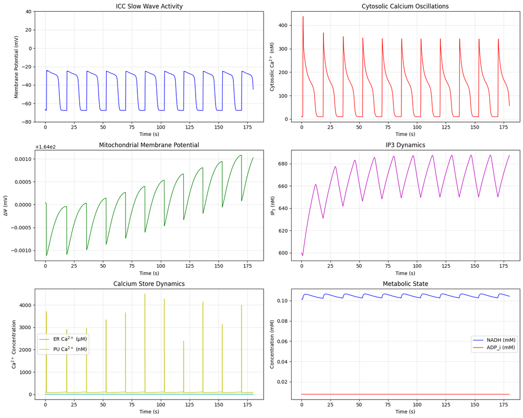

```
Slow Wave Analysis:
Number of slow waves: 11
Frequency: 59.16 Hz (16.9 ms period)
Amplitude: 42.70 mV
Peak membrane potential: -24.12 mV
Resting membrane potential: -67.66 mV

Final values (t = 180.0 s):
Vm = -44.588365 mV
Ca_i = 5.630665e-05 mM
IP3 = 6.873804e-04 mM
deltaPsi = 164.001026 mV
```

```python
    # Membrane potential (focus on slow waves)
    axes[0, 0].plot(t, Y[1, :], 'b-', linewidth=1)
    axes[0, 0].set_ylabel('Membrane Potential (mV)')
    axes[0, 0].set_xlabel('Time (s)')
    axes[0, 0].set_title('ICC Slow Wave Activity')
    axes[0, 0].grid(True, alpha=0.3)
    axes[0, 0].set_ylim([-80, 40])

    # Cytosolic calcium
    axes[0, 1].plot(t, Y[0, :] * 1e6, 'r-', linewidth=1)
    axes[0, 1].set_ylabel('Cytosolic Ca$^{2+}$ (nM)')
    axes[0, 1].set_xlabel('Time (s)')
    axes[0, 1].set_title('Cytosolic Calcium Oscillations')
    axes[0, 1].grid(True, alpha=0.3)

    # Mitochondrial membrane potential
    axes[1, 0].plot(t, Y[8, :], 'g-', linewidth=1)
    axes[1, 0].set_ylabel('ΔΨ (mV)')
    axes[1, 0].set_xlabel('Time (s)')
    axes[1, 0].set_title('Mitochondrial Membrane Potential')
    axes[1, 0].grid(True, alpha=0.3)

    # IP3 concentration
    axes[1, 1].plot(t, Y[22, :] * 1e6, 'm-', linewidth=1)
    axes[1, 1].set_ylabel('IP$_3$ (nM)')
    axes[1, 1].set_xlabel('Time (s)')
    axes[1, 1].set_title('IP3 Dynamics')
    axes[1, 1].grid(True, alpha=0.3)

    # Calcium stores
    axes[2, 0].plot(t, Y[4, :] * 1e3, 'c-', label='ER Ca$^{2+}$ (μM)', linewidth=1)
    axes[2, 0].plot(t, Y[5, :] * 1e6, 'y-', label='PU Ca$^{2+}$ (nM)', linewidth=1)
    axes[2, 0].set_ylabel('Ca$^{2+}$ Concentration')
    axes[2, 0].set_xlabel('Time (s)')
    axes[2, 0].set_title('Calcium Store Dynamics')
    axes[2, 0].legend()
    axes[2, 0].grid(True, alpha=0.3)

    # Metabolic state
    axes[2, 1].plot(t, Y[7, :], 'b-', label='NADH (mM)', linewidth=1)
    axes[2, 1].plot(t, Y[2, :], 'r-', label='ADP_i (mM)', linewidth=1)
    axes[2, 1].set_ylabel('Concentration (mM)')
    axes[2, 1].set_xlabel('Time (s)')
    axes[2, 1].set_title('Metabolic State')
    axes[2, 1].legend()
    axes[2, 1].grid(True, alpha=0.3)

    plt.tight_layout()
    plt.show()

    return fig

# Analyze slow wave properties
def analyze_slow_waves(t, Vm):
    """Analyze slow wave properties from membrane potential"""

    # Find peaks (slow wave depolarizations)
    from scipy.signal import find_peaks

    peaks, properties = find_peaks(Vm, height=-40, distance=100)

    if len(peaks) > 1:
        periods = np.diff(t[peaks])
        frequency = 1000 / np.mean(periods)  # Convert to Hz (periods in ms)
        amplitude = np.mean(properties['peak_heights'] - Vm[peaks-50])

        print(f"Slow Wave Analysis:")
        print(f"Number of slow waves: {len(peaks)}")
        print(f"Frequency: {frequency:.2f} Hz ({1000/frequency:.1f} ms period)")
        print(f"Amplitude: {amplitude:.2f} mV")
        print(f"Peak membrane potential: {np.max(Vm[peaks]):.2f} mV")
        print(f"Resting membrane potential: {np.min(Vm):.2f} mV")

    return peaks

# Run the simulation
if __name__ == "__main__":
    print("Solving ICC model...")
    print("Initial conditions and beta value")
    print(f"Beta = {2.6e-5}")

    t, Y = solve_ICC_model(t_span=(0, 180), beta=2.6e-5)
    print("Simulation completed. Plotting results...")

    fig = plot_results(t, Y)

    # Analyze slow waves
    peaks = analyze_slow_waves(t, Y[1, :])

    # Print final values
    print(f"\nFinal values (t = {t[-1]:.1f} s):")
    print(f"Vm = {Y[1, -1]:.6f} mV")
    print(f"Ca_i = {Y[0, -1]:.6e} mM")
    print(f"IP3 = {Y[22, -1]:.6e} mM")
    print(f"deltaPsi = {Y[8, -1]:.6f} mV")
```

# Limitations of Detailed ICC Plateau Models (e.g., Corrias–Buist-Type Models)

While biophysically detailed ICC models provide mechanistic accuracy, they also come with several practical disadvantages:

- **High computational cost:**  
  These models contain tens of ionic currents, gating variables, calcium compartments, mitochondrial energetics, and IP3 pathways. Solving these stiff ODE systems requires very small time steps and implicit solvers, making long simulations (e.g., whole-stomach slow-wave propagation) computationally expensive.
- **Large number of parameters:**  
  Each ionic current includes activation/inactivation gates, time constants, conductances, and reversal potentials. Calcium and metabolic pathways introduce additional pump rates, buffering ratios, flux constants, and volume fractions.  
  This leads to **hundreds of parameters**, many of which are only loosely constrained by experimental measurements.
- **Poor identifiability:**  
  Small changes in conductances or calcium flux terms can dramatically alter the plateau duration, frequency, and propagation speed.  
  As a result, parameter estimation becomes difficult, non-unique, and sensitive to dataset variability.
- **Limited generalizability:**  
  These models are *cell-type specific* and tuned for ICCs. They do **not generalize** to smooth muscle cells, cardiac AP, or other gastrointestinal cell types without significant re-parameterization.
- **Difficult to scale to organ-level simulations:**  
  Simulating hundreds or thousands of coupled ICCs (e.g., full stomach or small intestine) becomes computationally infeasible. Tissue- or organ-level modeling requires simplification beyond these biophysical frameworks.
- **Not ideal for control, optimization, or embedded applications:**  
  Real-time tasks such as model predictive control, parameter sweeps, or uncertainty quantification require fast evaluation—something detailed ICC models struggle to provide.

## Need for Generalized, Low-Cost Models for Plateau Potentials

Because of the above challenges, researchers often seek **reduced-order models** that can still reproduce the essential plateau dynamics but with drastically lower computational cost.

A promising approach is to use **generalized neuron models**, originally developed for excitable systems, but modified to capture plateau-like behavior. One such family includes **FitzHugh–Nagumo (FHN)-type or Morris–Lecar-type models**, which can be tuned to reproduce slow depolarization, sustained plateaus, or bursting-like waveforms.

### Advantages of Generalized (Reduced-Order) Models

- **Computationally efficient:**  
  Typically 2–3 ODEs, easily integrated with large time steps.  
  Suitable for organ-level simulations and real-time control.
- **Parameter-light:**  
  Only a small set of parameters control excitability, recovery, and plateau duration.  
  Easier to fit to experimental slow-wave recordings or imaging data.
- **Flexible and adaptable:**  
  Can be tuned to mimic ICC slow waves, smooth muscle potentials, or even pathological rhythms (tachygastria, bradygastria).
- **Analytically tractable:**  
  Phase-plane and bifurcation analysis help characterize regimes of oscillations, plateaus, or depolarization blocks.
- **Good for multi-scale frameworks:**  
  Can serve as the "cell model" inside larger stomach or intestine simulations with hundreds of compartments or networks.

## Example: A Generalized Plateau-Generating Model (FitzHugh–Nagumo Variant)

A modified FHN model can reproduce ICC-like plateaus by adding:

- a **cubic or bistable voltage nullcline**,
- a **slow recovery variable**, and
- an optional **slow Ca²⁺-like inactivation variable**.

This yields slow depolarizing ramps, broad plateaus, and periodic oscillations with tunable frequency—capturing the *phenomenology* of ICC slow waves without the full ionic detail.

## Summary

- **Detailed ICC models** provide deep mechanistic insight but are slow, sensitive to parameters, and difficult to scale.
- **Generalized reduced-order models** (modified FitzHugh–Nagumo, Morris–Lecar, or hybrid excitable–plateau systems) preserve the key features of plateau potentials while offering drastically lower computational cost.
- For large-scale simulations—such as stomach-wide slow-wave propagation, control design, or real-time estimation—these simplified models provide a practical and physiologically inspired alternative.

# Modified FitzHugh–Nagumo Model for Plateau-Like Slow Waves

This section presents the derivation, explanation, and complete implementation of a modified FitzHugh–Nagumo (FHN) model used to generate plateau-type slow-wave dynamics

## Model

### 1 Classical FitzHugh–Nagumo Model [5]

The original FHN equations are: $$ \frac{du}{dt} = f(u) - v + I,\qquad \frac{dv}{dt} = \epsilon (u - \gamma v) $$

where

- $u$ = membrane potential
- $v$ = recovery/slow inhibitory variable
- $\epsilon \ll 1$ ensures slow recovery
- $f(u)$ is a cubic function generating excitability

## 2 Modified Activation Term for Plateau Potentials [6]

To reproduce plateau-like slow depolarizations, we replace the cubic polynomial with a **tunable sigmoidal-like cubic**:

$$ f(u) = k\, u(u-a)(1-u) $$

This form ensures:

- **Threshold** at $u=a$
- **Saturation** at $u=1$
- **Excitability and plateau** controlled by parameter (k)

Thus the membrane potential equation becomes: $$ \frac{du}{dt} = k\,u(u-a)(1-u) - v $$

## 3 Modified Recovery Equation

$$ \frac{dv}{dt} = \epsilon \left( \gamma (u - \beta) - v \right) $$

where:

- $\gamma$ controls the strength of slow inhibition
- $\beta$ shifts the nullcline to tune oscillation frequency
- $\epsilon$ sets the slow-timescale (small → slow waves). This value can be used to chnage the frequency of slow waves. Smaller value leads to lower frequency, higher value leads to higher frequency

## 4 Final Model

$$ \boxed{ \begin{aligned} \frac{du}{dt} &= k\,u(u-a)(1-u) - v \\ \frac{dv}{dt} &= \epsilon \left[\gamma (u - \beta) - v \right] \end{aligned}} $$

This model produces stable, tunable, plateau-like oscillations with extremely low computational cost—ideal for whole-organ gastric models.

## Code for Modified FitzHugh–Nagumo Model for Plateau-Like Slow Waves

```
Times at consecutive peaks (ms):
[ 16.008004    63.53176588 111.05552776 158.57928964]
Estimated frequency (cycles/min): 1.263
```

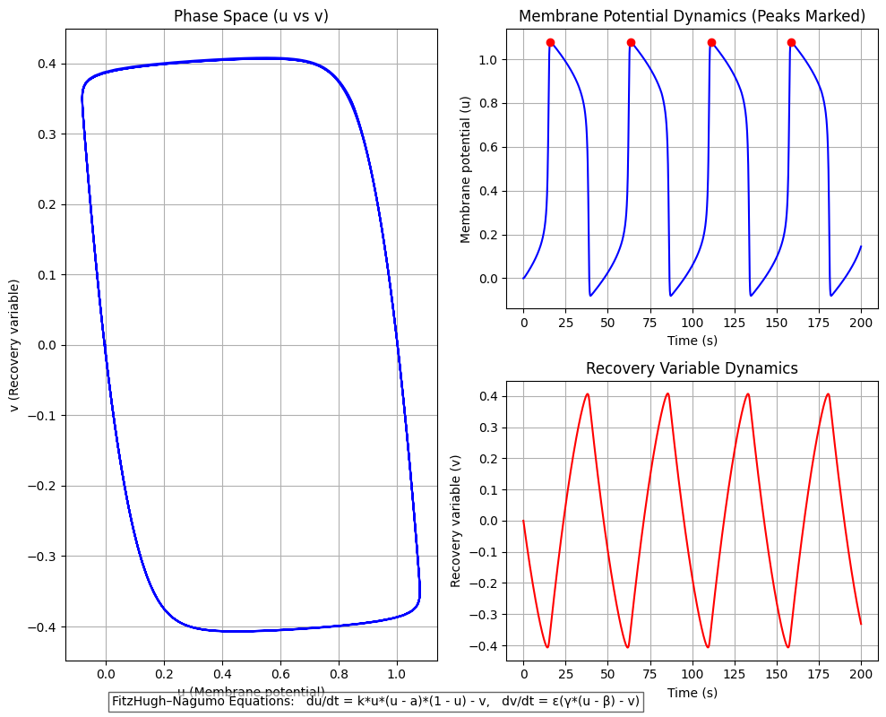

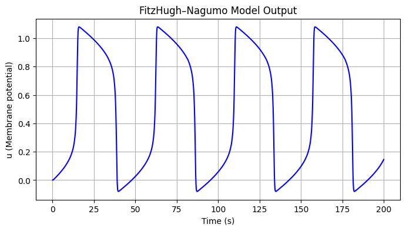

```python
import numpy as np
import matplotlib.pyplot as plt
from scipy.integrate import solve_ivp

# FitzHugh-Nagumo ODE system
def fhn_ode(t, y, k, a, beta, gamma, eps_val):
    u, v = y
    du = k * u * (u - a) * (1 - u) - v
    dv = eps_val * (gamma * (u - beta) - v)
    return [du, dv]

# Parameters
k = 7
a = 0.5
beta = 0.5
gamma = 8
sigma = 0.04
eps_val = 0.01

# Time span
t_span = (0, 200)
t_eval = np.linspace(t_span[0], t_span[1], 2000)

# Initial conditions
y0 = [0.0, 0.0]

# Solve ODE
sol = solve_ivp(fhn_ode, t_span, y0, t_eval=t_eval, args=(k, a, beta, gamma, eps_val), method='LSODA')

t = sol.t
u = sol.y[0]
v = sol.y[1]

# --- PEAK DETECTION ---
du = np.diff(u)
peak_indices = np.where((du[:-1] > 0) & (du[1:] < 0))[0] + 1
peak_times = t[peak_indices]

# Compute frequency between last two peaks (convert period to per minute)
if len(peak_times) >= 2:
    peak_calc_last_1 = peak_times[-1]
    peak_calc_last_2 = peak_times[-2]
    frequency_time = 60.0 / (peak_calc_last_1 - peak_calc_last_2)
else:
    frequency_time = np.nan

print("Times at consecutive peaks (ms):")
print(peak_times)
print(f"Estimated frequency (cycles/min): {frequency_time:.3f}")

# --- PLOTS ---
plt.figure(figsize=(10, 8))

# Phase space plot (u-v)
plt.subplot(2, 2, (1, 3))
plt.plot(u, v, 'b')
plt.xlabel("u (Membrane potential)")
plt.ylabel("v (Recovery variable)")
plt.title("Phase Space (u vs v)")
plt.grid(True)

# Membrane potential over time
plt.subplot(2, 2, 2)
plt.plot(t, u, 'b', linewidth=1.5)
plt.plot(peak_times, u[peak_indices], 'ro', markersize=6)
plt.xlabel("Time (s)")
plt.ylabel("Membrane potential (u)")
plt.title("Membrane Potential Dynamics (Peaks Marked)")
plt.grid(True)

# Recovery variable over time
plt.subplot(2, 2, 4)
plt.plot(t, v, 'r', linewidth=1.5)
plt.xlabel("Time (s)")
plt.ylabel("Recovery variable (v)")
plt.title("Recovery Variable Dynamics")
plt.grid(True)

plt.tight_layout()

# Display the model equations
plt.figtext(0.13, 0.01,
            "FitzHugh–Nagumo Equations:   du/dt = k*u*(u - a)*(1 - u) - v,   dv/dt = ε(γ*(u - β) - v)",
            ha="left", fontsize=10, bbox={"facecolor":"white", "alpha":0.6, "pad":3})

plt.show()

# Optional: quick plot of membrane potential
plt.figure(figsize=(8,4))
plt.plot(t, u, 'b')
plt.xlabel("Time (s)")
plt.ylabel("u (Membrane potential)")
plt.title("FitzHugh–Nagumo Model Output")
plt.grid(True)
plt.show()
```

# Limitations of the Modified FitzHugh–Nagumo (FNM) Model

While the modified FNM model provides a computationally inexpensive way to generate plateau-like oscillations, it also has several important limitations when applied to gastrointestinal slow-wave modeling:

- **Inaccurate slow-wave shape**  
  The model produces generic excitable-limit-cycle oscillations rather than the characteristic ICC slow-wave morphology (rapid upstroke → sustained plateau → gradual repolarization).  
  Fine-tuning parameters improves frequency but does not reproduce realistic waveform asymmetry or plateau rounding seen in experimental ICC recordings.
- **No biophysical ionic mechanisms**  
  The model lacks explicit Ca²⁺, Na⁺, K⁺, or store-operated currents that drive ICC pacemaking.  
  This limits its physiological interpretability and makes it unsuitable for studies involving pharmacological modulation, ion-channel dysfunction, or dysrhythmic mechanisms.
- **Poor integration with electro–chemo–mechanical coupling**  
  Because the FNM model outputs only a single abstract “membrane potential” variable, it cannot:
  - generate realistic intracellular Ca²⁺ transients,
  - drive Hill-type or cross-bridge muscle activation laws,
  - compute active stress generation in smooth muscle.  
    As a result, it cannot be directly linked to tissue mechanics or fluid–structure interactions in stomach models.

# Motivation for a Modified LIF-Type Slow-Wave Model

Given these limitations, a **modified Leaky Integrate-and-Fire (MLIF) model** becomes a more practical choice for full-system organ simulations:

- MLIF models are computationally cheap (1 differential equations)
- The slow-wave shape can be imposed analytically or through piecewise functions calibrated to organ action potential recordings.
- Plateau duration, upstroke slope, and repolarization slope can be controlled independently.
- A deterministic Ca²⁺ surrogate variable can be added for **electro–chemo–mechanical coupling**, enabling:
  - smooth muscle activation,
  - stress generation,
  - pressure/flow modeling.
- LIF models scale extremely well for:
  - stomach wall networks,
  - compartmental models,
  - MPC and real-time simulation for VNS control.

# Explanation of the Modified LIF for Plateau like Action Potential Model [7]

The modified Leaky Integrate-and-Fire (LIF) model is designed to reproduce organ action potentials with plateaus using a computationally inexpensive framework. This model uses a single ODE representing the membrane potential with a custom input current.

## 1. Governing Equation

The membrane potential of a compartment is given by:

$$ \frac{dV_m}{dt} = \frac{ I_{\text{ICC}}(t) \, e^{-s^2 t^2} - V_m(t) + V_{\text{rest}} } { e^{-s^2 t^2} } $$

### 1.1 Derivation

The classical LIF model has the form:

$$ \frac{dV}{dt} = -\frac{1}{\tau}(V - V_{\text{rest}}) + \frac{I(t)}{C_m} $$

To reproduce **plateau-like depolarization**, we modify the leak term using a **Gaussian envelope**:

- The leak is “weaker” during the plateau (slower repolarization).
- The envelope acts as a **time-varying conductance**:

$$ g_{\text{leak}}(t) = e^{-s^2 t^2} $$

Thus the generalized model becomes:

$$ g_{\text{leak}}(t)\frac{dV_m}{dt} = I_{\text{ICC}}(t) \, g_{\text{leak}}(t) - (V_m - V_{\text{rest}}) $$

Divide both sides by (g_{\text{leak}}(t)):

$$ \frac{dV_m}{dt} = \frac{I_{\text{ICC}}(t) g_{\text{leak}}(t) - (V_m - V_{\text{rest}})}{g_{\text{leak}}(t)} $$

This produces slow depolarization → sustained plateau → smooth repolarization, mimicking ICC slow waves.

## 2. ICC Input Current $\mathbf{I_{\text{ICC}}(t)}$

$$ I_{\text{ICC}}(t) = \begin{cases} 0, & t < t_{\text{start}} \\ \kappa, & 0 \le t_{\text{cyc}} \le t_{\text{open}} \\ 0, & t > t_{\text{open}} \end{cases} $$

Where:

- $t_{\text{start}} = H/c$ is the arrival time of the slow wave
- $H$ = compartment position
- $c$ = conduction velocity
- $t_{\text{open}}$ = plateau duration
- $\kappa$ = amplitude of the ICC current
- $t_{\text{cyc}} = t - t_{\text{start}} \mod T$ ensures periodicity

### Physiological meaning:

- Simulates **slow-wave propagation delay** along compartments
- Generates a **rectangular pacemaker current**, analogue to ICC activation
- Controls **slow-wave frequency and plateau width**

## 3. Gaussian Envelope

$$ e^{-s^2 t^2} $$

### Effect:

- Shapes the plateau region
- Reduces membrane repolarization rate
- Introduces smooth plateau decay instead of sharp falling phases

Control plateau by altering value of (s)

## Code for Modified LIF Model

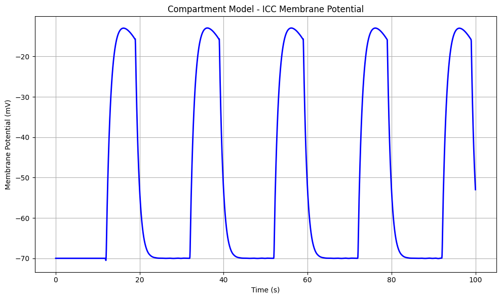

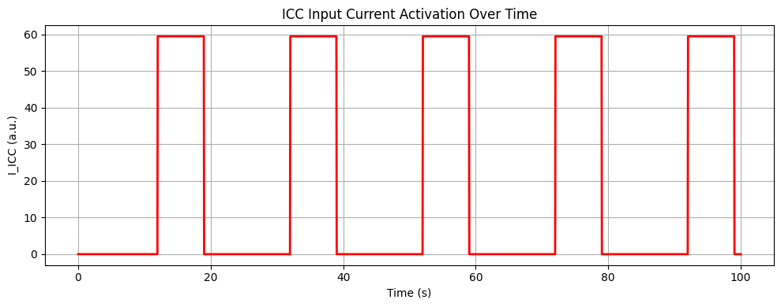

```python
import numpy as np
import matplotlib.pyplot as plt
from scipy.integrate import solve_ivp

# ---------------------------------------------------
# Compartment ODE function
# ---------------------------------------------------
def Compartment(time, y):
    """
    Compartment Function: Defines the system of ODEs for a single compartment.
    Equivalent to the MATLAB version.
    """

    # Parameters
    t_end = 20          # Time period of ICC wave (s)
    kappa = 59.53       # Maximum ICC current
    H_comp_1 = 3        # Length (cm)
    c_comp_1 = 0.25     # Conduction velocity (cm/s)
    s_ICC = 0.05        # Decay constant
    t_open = 7          # Time open for Compartment 1 (s)
    V_m_rest_ICC = -70  # Resting membrane potential (mV)

    # Extract state variable
    V_m_ICC_comp_1 = y[0]

    # Start time of activity
    t_start_comp_1 = H_comp_1 / c_comp_1
    time_cyc_comp_1 = time

    # Determine ICC input current
    if time_cyc_comp_1 < t_start_comp_1:
        I_ICC_comp_1 = 0
    else:
        time_cyc_comp_1 -= t_start_comp_1

        # Keep time within one period
        while time_cyc_comp_1 > t_end:
            time_cyc_comp_1 -= t_end

        # Active or inactive phase
        if time_cyc_comp_1 <= t_open:
            I_ICC_comp_1 = kappa
        else:
            I_ICC_comp_1 = 0

    # ODE for membrane potential
    dy1 = (I_ICC_comp_1 * np.exp(-s_ICC**2 * time_cyc_comp_1**2)
           - V_m_ICC_comp_1 + V_m_rest_ICC) / np.exp(-s_ICC**2 * time_cyc_comp_1**2)

    return [dy1]


# ---------------------------------------------------
# Solve the ODE
# ---------------------------------------------------
t_span = (0, 100)                   # Simulation time (s)
t_eval = np.linspace(t_span[0], t_span[1], 2000)
y0 = [-70]                          # Initial membrane potential (mV)

sol = solve_ivp(Compartment, t_span, y0, t_eval=t_eval, method='RK45')

# Extract solution
t = sol.t
V_m = sol.y[0]

# ---------------------------------------------------
# Plot results
# ---------------------------------------------------
plt.figure(figsize=(10, 6))
plt.plot(t, V_m, 'b', linewidth=2)
plt.title("Compartment Model - ICC Membrane Potential")
plt.xlabel("Time (s)")
plt.ylabel("Membrane Potential (mV)")
plt.grid(True)
plt.tight_layout()
plt.show()

# Optional: show ICC current activation periods
# (for visualization of wave cycles)
def I_ICC(time):
    t_end = 20
    kappa = 59.53
    H_comp_1 = 3
    c_comp_1 = 0.25
    t_open = 7
    t_start = H_comp_1 / c_comp_1
    time_cyc = np.copy(time)
    I = np.zeros_like(time)

    for i, t in enumerate(time):
        if t < t_start:
            I[i] = 0
        else:
            time_cyc = t - t_start
            while time_cyc > t_end:
                time_cyc -= t_end
            I[i] = kappa if time_cyc <= t_open else 0
    return I

I_vals = I_ICC(t)
plt.figure(figsize=(10, 4))
plt.plot(t, I_vals, 'r', linewidth=2)
plt.title("ICC Input Current Activation Over Time")
plt.xlabel("Time (s)")
plt.ylabel("I_ICC (a.u.)")
plt.grid(True)
plt.tight_layout()
plt.show()
```

# Limitations of the Modified LIF Slow-Wave Model

The modified LIF model provides a computationally efficient representation of ICC-like slow waves. However, it also has some limitations:

- **Entrainment not explicitly captured**  
  Entrainment or phse lockign of this model is yet to be studied
- **Simplified electrophysiology**  
  The model does not include ionic currents, calcium dynamics, or store-operated mechanisms, which limits its physiological interpretability.  
  Pharmacological manipulations, ion-channel dysfunction, or metabolic coupling cannot be directly simulated.
- **Approximate waveform**  
  While the plateau shape is tunable, the waveform does not fully reproduce experimental ICC slow-wave morphology.  
  Fine details such as subtle upstroke curvature or repolarization asymmetry are lost.

# Strengths for System-Level Modeling

Despite the above limitations, the modified LIF model is ideal for **closed-loop, compartmental, or organ-level simulations**:

- **Extremely fast computationally**  
  Single ODE per compartment → can scale to hundreds or thousands of compartments in real-time simulations.
- **Plateau-like slow waves**  
  Sufficient to drive downstream processes such as surrogate calcium dynamics, muscle contraction, or flow modeling.
- **Flexible for control applications**  
  Well-suited for **model-based closed-loop control** (e.g., vagal nerve stimulation) where approximate waveforms are sufficient for system-level feedback.
- **Easily tunable**  
  Parameters like plateau duration, frequency, and amplitude can be independently adjusted to match experimental data.

**Conclusion:** While unsuitable for detailed entrainment or ionic studies, the modified LIF model provides a practical, fast, and tunable framework for **compartmental organ simulations and real-time control applications**.

# References

1. HODGKIN AL, HUXLEY AF. A quantitative description of membrane current and its application to conduction and excitation in nerve. J Physiol. 1952 Aug;117(4):500-44. doi: 10.1113/jphysiol.1952.sp004764. PMID: 12991237; PMCID: PMC1392413.
2. Gabbiani, F., & Cox, S. J. (2017). Mathematics for neuroscientists. Academic Press.
3. E. M. Izhikevich, "Simple model of spiking neurons," in IEEE Transactions on Neural Networks, vol. 14, no. 6, pp. 1569-1572, Nov. 2003, doi: 10.1109/TNN.2003.820440. keywords: {Neurons;Biological system modeling;Brain modeling;Computational modeling;Biomembranes;Biology computing;Large-scale systems;Mathematical analysis;Mathematical model;Bifurcation},
4. Corrias, A., & Buist, M. L. (2008). Quantitative cellular description of gastric slow wave activity. American Journal of Physiology-Gastrointestinal and Liver Physiology, 294(4), G989-G995.
5. FitzHugh, R. (1961). "Impulses and physiological states in theoretical models of nerve membrane." Biophysical Journal, 1(6), 445–466 and Nagumo, J., Arimoto, S., & Yoshizawa, S. (1962). "An Active Pulse Transmission Line Simulating Nerve Axon." Proceedings of the IRE, 50(10), 2061–2070.
6. Cheng, L. K., Komuro, R., Austin, T. M., Buist, M. L., & Pullan, A. J. (2007). Anatomically realistic multiscale models of normal and abnormal gastrointestinal electrical activity. World journal of gastroenterology: WJG, 13(9), 1378.
7. Fernandes, S. Q., Kothare, M. V., & Mahmoudi, B. (2024). A novel compartmental approach for modeling stomach motility and gastric emptying. Computers in Biology and Medicine, 181, 109035.